# Credit Card Users Churn Prediction

## Problem Statement

### Business Context

The Thera bank recently saw a steep decline in the number of users of their credit card, credit cards are a good source of income for banks because of different kinds of fees charged by the banks like annual fees, balance transfer fees, and cash advance fees, late payment fees, foreign transaction fees, and others. Some fees are charged to every user irrespective of usage, while others are charged under specified circumstances.

Customers’ leaving credit cards services would lead bank to loss, so the bank wants to analyze the data of customers and identify the customers who will leave their credit card services and reason for same – so that bank could improve upon those areas

You as a Data scientist at Thera bank need to come up with a classification model that will help the bank improve its services so that customers do not renounce their credit cards

### Data Description

- CLIENTNUM: Client number. Unique identifier for the customer holding the account
- Attrition_Flag: Internal event (customer activity) variable - if the account is closed then "Attrited Customer" else "Existing Customer"
- Customer_Age: Age in Years
- Gender: Gender of the account holder
- Dependent_count: Number of dependents
- Education_Level: Educational Qualification of the account holder - Graduate, High School, Unknown, Uneducated, College(refers to college student), Post-Graduate, Doctorate
- Marital_Status: Marital Status of the account holder
- Income_Category: Annual Income Category of the account holder
- Card_Category: Type of Card
- Months_on_book: Period of relationship with the bank (in months)
- Total_Relationship_Count: Total no. of products held by the customer
- Months_Inactive_12_mon: No. of months inactive in the last 12 months
- Contacts_Count_12_mon: No. of Contacts in the last 12 months
- Credit_Limit: Credit Limit on the Credit Card
- Total_Revolving_Bal: Total Revolving Balance on the Credit Card
- Avg_Open_To_Buy: Open to Buy Credit Line (Average of last 12 months)
- Total_Amt_Chng_Q4_Q1: Change in Transaction Amount (Q4 over Q1)
- Total_Trans_Amt: Total Transaction Amount (Last 12 months)
- Total_Trans_Ct: Total Transaction Count (Last 12 months)
- Total_Ct_Chng_Q4_Q1: Change in Transaction Count (Q4 over Q1)
- Avg_Utilization_Ratio: Average Card Utilization Ratio

#### What Is a Revolving Balance?

- If we don't pay the balance of the revolving credit account in full every month, the unpaid portion carries over to the next month. That's called a revolving balance

##### What is the Average Open to buy?

- 'Open to Buy' means the amount left on your credit card to use. Now, this column represents the average of this value for the last 12 months.

##### What is the Average utilization Ratio?

- The Avg_Utilization_Ratio represents how much of the available credit the customer spent. This is useful for calculating credit scores.

##### Relation b/w Avg_Open_To_Buy, Credit_Limit and Avg_Utilization_Ratio:

- ( Avg_Open_To_Buy / Credit_Limit ) + Avg_Utilization_Ratio = 1

### **Please read the instructions carefully before starting the project.**

This is a commented Jupyter IPython Notebook file in which all the instructions and tasks to be performed are mentioned.

- Blanks '_______' are provided in the notebook that needs to be filled with an appropriate code to get the correct result. With every '_______' blank, there is a comment that briefly describes what needs to be filled in the blank space.
- Identify the task to be performed correctly, and only then proceed to write the required code.
- Fill the code wherever asked by the commented lines like "# write your code here" or "# complete the code". Running incomplete code may throw error.
- Please run the codes in a sequential manner from the beginning to avoid any unnecessary errors.
- Add the results/observations (wherever mentioned) derived from the analysis in the presentation and submit the same.

## Importing necessary libraries

```python
# Installing the libraries with the specified version.
# uncomment and run the following line if Google Colab is being used
!pip install scikit-learn==1.1.3 seaborn==0.13.1 matplotlib==3.7.1 numpy==1.25.2 pandas==1.5.3 imbalanced-learn==0.10.1 xgboost==2.0.3 -q --user
```

[output not shown]

```python
# Installing the libraries with the specified version.
# uncomment and run the following lines if Jupyter Notebook is being used
# !pip install scikit-learn==1.2.2 seaborn==0.13.1 matplotlib==3.7.1 numpy==1.25.2 pandas==1.5.3 imblearn==0.12.0 xgboost==2.0.3 -q --user
#!pip install --upgrade -q threadpoolctl
```

**Note**: *After running the above cell, kindly restart the notebook kernel and run all cells sequentially from the start again*.

```python
import pandas as pd
import numpy as np
import matplotlib.pyplot as plt
import seaborn as sns
import sklearn

from sklearn.model_selection import train_test_split
from sklearn.metrics import accuracy_score, recall_score, precision_score, f1_score, confusion_matrix, make_scorer
from sklearn.linear_model import LogisticRegression
from sklearn.tree import DecisionTreeClassifier
from sklearn.ensemble import RandomForestClassifier, AdaBoostClassifier, GradientBoostingClassifier, BaggingClassifier
from xgboost import XGBClassifier

from sklearn.preprocessing import StandardScaler
from sklearn.model_selection import GridSearchCV
from sklearn.model_selection import RandomizedSearchCV
from sklearn import metrics

from imblearn.over_sampling import SMOTE
from imblearn.under_sampling import RandomUnderSampler

# To define maximum number of columns to be displayed in a dataframe
pd.set_option("display.max_columns", None)
```

```python
from google.colab import drive
drive.mount('/content/drive')
```

## Loading the dataset

```python
data = pd.read_csv('/content/drive/MyDrive/PGP-AIML Program/Projects/Project 3 - Credit Card Users Churn Prediction/BankChurners.csv')
```

```python
df = data.copy()  # Copy of the data
```

```python
df.head()
```

|  | CLIENTNUM | Attrition_Flag | Customer_Age | Gender | Dependent_count | Education_Level | Marital_Status | Income_Category | Card_Category | Months_on_book | ... | Months_Inactive_12_mon | Contacts_Count_12_mon | Credit_Limit | Total_Revolving_Bal | Avg_Open_To_Buy | Total_Amt_Chng_Q4_Q1 | Total_Trans_Amt | Total_Trans_Ct | Total_Ct_Chng_Q4_Q1 | Avg_Utilization_Ratio |
| --- | --- | --- | --- | --- | --- | --- | --- | --- | --- | --- | --- | --- | --- | --- | --- | --- | --- | --- | --- | --- | --- |
| 0 | 768805383 | Existing Customer | 45 | M | 3 | High School | Married | $60K - $80K | Blue | 39 | ... | 1 | 3 | 12691.0 | 777 | 11914.0 | 1.335 | 1144 | 42 | 1.625 | 0.061 |
| 1 | 818770008 | Existing Customer | 49 | F | 5 | Graduate | Single | Less than $40K | Blue | 44 | ... | 1 | 2 | 8256.0 | 864 | 7392.0 | 1.541 | 1291 | 33 | 3.714 | 0.105 |
| 2 | 713982108 | Existing Customer | 51 | M | 3 | Graduate | Married | $80K - $120K | Blue | 36 | ... | 1 | 0 | 3418.0 | 0 | 3418.0 | 2.594 | 1887 | 20 | 2.333 | 0.000 |
| 3 | 769911858 | Existing Customer | 40 | F | 4 | High School | NaN | Less than $40K | Blue | 34 | ... | 4 | 1 | 3313.0 | 2517 | 796.0 | 1.405 | 1171 | 20 | 2.333 | 0.760 |
| 4 | 709106358 | Existing Customer | 40 | M | 3 | Uneducated | Married | $60K - $80K | Blue | 21 | ... | 1 | 0 | 4716.0 | 0 | 4716.0 | 2.175 | 816 | 28 | 2.500 | 0.000 |

5 rows × 21 columns

- 10,127 rows
- 21 columns

## Data Overview

- Observations
- Sanity checks

```python
df.info()
```

```
<class 'pandas.core.frame.DataFrame'>
RangeIndex: 10127 entries, 0 to 10126
Data columns (total 21 columns):
 #   Column                    Non-Null Count  Dtype
---  ------                    --------------  -----
 0   CLIENTNUM                 10127 non-null  int64
 1   Attrition_Flag            10127 non-null  object
 2   Customer_Age              10127 non-null  int64
 3   Gender                    10127 non-null  object
 4   Dependent_count           10127 non-null  int64
 5   Education_Level           8608 non-null   object
 6   Marital_Status            9378 non-null   object
 7   Income_Category           10127 non-null  object
 8   Card_Category             10127 non-null  object
 9   Months_on_book            10127 non-null  int64
 10  Total_Relationship_Count  10127 non-null  int64
 11  Months_Inactive_12_mon    10127 non-null  int64
 12  Contacts_Count_12_mon     10127 non-null  int64
 13  Credit_Limit              10127 non-null  float64
 14  Total_Revolving_Bal       10127 non-null  int64
 15  Avg_Open_To_Buy           10127 non-null  float64
 16  Total_Amt_Chng_Q4_Q1      10127 non-null  float64
 17  Total_Trans_Amt           10127 non-null  int64
 18  Total_Trans_Ct            10127 non-null  int64
 19  Total_Ct_Chng_Q4_Q1       10127 non-null  float64
 20  Avg_Utilization_Ratio     10127 non-null  float64
dtypes: float64(5), int64(10), object(6)
memory usage: 1.6+ MB
```

- 5 decimals
- 10 integers
- 6 strings(objects)
- Target feature: Attrition_Flag

```python
df.describe().T
```

|  | count | mean | std | min | 25% | 50% | 75% | max |
| --- | --- | --- | --- | --- | --- | --- | --- | --- |
| CLIENTNUM | 10127.0 | 7.391776e+08 | 3.690378e+07 | 708082083.0 | 7.130368e+08 | 7.179264e+08 | 7.731435e+08 | 8.283431e+08 |
| Customer_Age | 10127.0 | 4.632596e+01 | 8.016814e+00 | 26.0 | 4.100000e+01 | 4.600000e+01 | 5.200000e+01 | 7.300000e+01 |
| Dependent_count | 10127.0 | 2.346203e+00 | 1.298908e+00 | 0.0 | 1.000000e+00 | 2.000000e+00 | 3.000000e+00 | 5.000000e+00 |
| Months_on_book | 10127.0 | 3.592841e+01 | 7.986416e+00 | 13.0 | 3.100000e+01 | 3.600000e+01 | 4.000000e+01 | 5.600000e+01 |
| Total_Relationship_Count | 10127.0 | 3.812580e+00 | 1.554408e+00 | 1.0 | 3.000000e+00 | 4.000000e+00 | 5.000000e+00 | 6.000000e+00 |
| Months_Inactive_12_mon | 10127.0 | 2.341167e+00 | 1.010622e+00 | 0.0 | 2.000000e+00 | 2.000000e+00 | 3.000000e+00 | 6.000000e+00 |
| Contacts_Count_12_mon | 10127.0 | 2.455317e+00 | 1.106225e+00 | 0.0 | 2.000000e+00 | 2.000000e+00 | 3.000000e+00 | 6.000000e+00 |
| Credit_Limit | 10127.0 | 8.631954e+03 | 9.088777e+03 | 1438.3 | 2.555000e+03 | 4.549000e+03 | 1.106750e+04 | 3.451600e+04 |
| Total_Revolving_Bal | 10127.0 | 1.162814e+03 | 8.149873e+02 | 0.0 | 3.590000e+02 | 1.276000e+03 | 1.784000e+03 | 2.517000e+03 |
| Avg_Open_To_Buy | 10127.0 | 7.469140e+03 | 9.090685e+03 | 3.0 | 1.324500e+03 | 3.474000e+03 | 9.859000e+03 | 3.451600e+04 |
| Total_Amt_Chng_Q4_Q1 | 10127.0 | 7.599407e-01 | 2.192068e-01 | 0.0 | 6.310000e-01 | 7.360000e-01 | 8.590000e-01 | 3.397000e+00 |
| Total_Trans_Amt | 10127.0 | 4.404086e+03 | 3.397129e+03 | 510.0 | 2.155500e+03 | 3.899000e+03 | 4.741000e+03 | 1.848400e+04 |
| Total_Trans_Ct | 10127.0 | 6.485869e+01 | 2.347257e+01 | 10.0 | 4.500000e+01 | 6.700000e+01 | 8.100000e+01 | 1.390000e+02 |
| Total_Ct_Chng_Q4_Q1 | 10127.0 | 7.122224e-01 | 2.380861e-01 | 0.0 | 5.820000e-01 | 7.020000e-01 | 8.180000e-01 | 3.714000e+00 |
| Avg_Utilization_Ratio | 10127.0 | 2.748936e-01 | 2.756915e-01 | 0.0 | 2.300000e-02 | 1.760000e-01 | 5.030000e-01 | 9.990000e-01 |

- The average age of the account holder is 46 years
- The maximum age of the account holder is 73 years
- The average credit limit 8,632
- The average total revolving balance is 1,163
- The average total number of transactions is 65

**Fixing Data Types**

```python
cols = df.select_dtypes(['object'])
cols.columns
```

```
Index(['Attrition_Flag', 'Gender', 'Education_Level', 'Marital_Status',
       'Income_Category', 'Card_Category'],
      dtype='object')
```

- These are the object datatypes

```python
for i in cols.columns:
  df[i] = df[i].astype('category')
```

- Converting these object to categories

```python
df.info()
```

```
<class 'pandas.core.frame.DataFrame'>
RangeIndex: 10127 entries, 0 to 10126
Data columns (total 21 columns):
 #   Column                    Non-Null Count  Dtype
---  ------                    --------------  -----
 0   CLIENTNUM                 10127 non-null  int64
 1   Attrition_Flag            10127 non-null  category
 2   Customer_Age              10127 non-null  int64
 3   Gender                    10127 non-null  category
 4   Dependent_count           10127 non-null  int64
 5   Education_Level           8608 non-null   category
 6   Marital_Status            9378 non-null   category
 7   Income_Category           10127 non-null  category
 8   Card_Category             10127 non-null  category
 9   Months_on_book            10127 non-null  int64
 10  Total_Relationship_Count  10127 non-null  int64
 11  Months_Inactive_12_mon    10127 non-null  int64
 12  Contacts_Count_12_mon     10127 non-null  int64
 13  Credit_Limit              10127 non-null  float64
 14  Total_Revolving_Bal       10127 non-null  int64
 15  Avg_Open_To_Buy           10127 non-null  float64
 16  Total_Amt_Chng_Q4_Q1      10127 non-null  float64
 17  Total_Trans_Amt           10127 non-null  int64
 18  Total_Trans_Ct            10127 non-null  int64
 19  Total_Ct_Chng_Q4_Q1       10127 non-null  float64
 20  Avg_Utilization_Ratio     10127 non-null  float64
dtypes: category(6), float64(5), int64(10)
memory usage: 1.2 MB
```

- The memory usage decreased a little by changing object to category

```python
df.describe(include=['category']).T
```

|  | count | unique | top | freq |
| --- | --- | --- | --- | --- |
| Attrition_Flag | 10127 | 2 | Existing Customer | 8500 |
| Gender | 10127 | 2 | F | 5358 |
| Education_Level | 8608 | 6 | Graduate | 3128 |
| Marital_Status | 9378 | 3 | Married | 4687 |
| Income_Category | 10127 | 6 | Less than $40K | 3561 |
| Card_Category | 10127 | 4 | Blue | 9436 |

- It shows the category data types

**Dropping not important features**

```python
df.drop('CLIENTNUM',axis=1,inplace=True)
```

- Dropping not used column

**Unique features of all categories**

```python
cols_cat= df.select_dtypes(['category'])
```

```python
for i in cols_cat.columns:
  print('Unique values in',i, 'are :')
  print(cols_cat[i].value_counts())
  print('*'*50)
```

```
Unique values in Attrition_Flag are :
Attrition_Flag
Existing Customer    8500
Attrited Customer    1627
Name: count, dtype: int64
Unique values in Gender are :
Gender
F    5358
M    4769
Name: count, dtype: int64
Unique values in Education_Level are :
Education_Level
Graduate         3128
High School      2013
Uneducated       1487
College          1013
Post-Graduate     516
Doctorate         451
Name: count, dtype: int64
Unique values in Marital_Status are :
Marital_Status
Married     4687
Single      3943
Divorced     748
Name: count, dtype: int64
Unique values in Income_Category are :
Income_Category
Less than $40K    3561
$40K - $60K       1790
$80K - $120K      1535
$60K - $80K       1402
abc               1112
$120K +            727
Name: count, dtype: int64
Unique values in Card_Category are :
Card_Category
Blue        9436
Silver       555
Gold         116
Platinum      20
Name: count, dtype: int64
```

- Shows the categories for features

## Exploratory Data Analysis (EDA)

- EDA is an important part of any project involving data.
- It is important to investigate and understand the data better before building a model with it.
- A few questions have been mentioned below which will help you approach the analysis in the right manner and generate insights from the data.
- A thorough analysis of the data, in addition to the questions mentioned below, should be done.

**Questions**:

1. How is the total transaction amount distributed?
2. What is the distribution of the level of education of customers?
3. What is the distribution of the level of income of customers?
4. How does the change in transaction amount between Q4 and Q1 (`total_ct_change_Q4_Q1`) vary by the customer's account status (`Attrition_Flag`)?
5. How does the number of months a customer was inactive in the last 12 months (`Months_Inactive_12_mon`) vary by the customer's account status (`Attrition_Flag`)?
6. What are the attributes that have a strong correlation with each other?

#### The below functions need to be defined to carry out the Exploratory Data Analysis.

```python
# function to plot a boxplot and a histogram along the same scale.


def histogram_boxplot(data, feature, figsize=(12, 7), kde=False, bins=None):
    """
    Boxplot and histogram combined

    data: dataframe
    feature: dataframe column
    figsize: size of figure (default (12,7))
    kde: whether to the show density curve (default False)
    bins: number of bins for histogram (default None)
    """
    f2, (ax_box2, ax_hist2) = plt.subplots(
        nrows=2,  # Number of rows of the subplot grid= 2
        sharex=True,  # x-axis will be shared among all subplots
        gridspec_kw={"height_ratios": (0.25, 0.75)},
        figsize=figsize,
    )  # creating the 2 subplots
    sns.boxplot(
        data=data, x=feature, ax=ax_box2, showmeans=True, color="violet"
    )  # boxplot will be created and a triangle will indicate the mean value of the column
    sns.histplot(
        data=data, x=feature, kde=kde, ax=ax_hist2, bins=bins, palette="winter"
    ) if bins else sns.histplot(
        data=data, x=feature, kde=kde, ax=ax_hist2
    )  # For histogram
    ax_hist2.axvline(
        data[feature].mean(), color="green", linestyle="--"
    )  # Add mean to the histogram
    ax_hist2.axvline(
        data[feature].median(), color="black", linestyle="-"
    )  # Add median to the histogram
```

```python
# function to create labeled barplots


def labeled_barplot(data, feature, perc=False, n=None):
    """
    Barplot with percentage at the top

    data: dataframe
    feature: dataframe column
    perc: whether to display percentages instead of count (default is False)
    n: displays the top n category levels (default is None, i.e., display all levels)
    """

    total = len(data[feature])  # length of the column
    count = data[feature].nunique()
    if n is None:
        plt.figure(figsize=(count + 1, 5))
    else:
        plt.figure(figsize=(n + 1, 5))

    plt.xticks(rotation=90, fontsize=15)
    ax = sns.countplot(
        data=data,
        x=feature,
        palette="Paired",
        order=data[feature].value_counts().index[:n].sort_values(),
    )

    for p in ax.patches:
        if perc == True:
            label = "{:.1f}%".format(
                100 * p.get_height() / total
            )  # percentage of each class of the category
        else:
            label = p.get_height()  # count of each level of the category

        x = p.get_x() + p.get_width() / 2  # width of the plot
        y = p.get_height()  # height of the plot

        ax.annotate(
            label,
            (x, y),
            ha="center",
            va="center",
            size=12,
            xytext=(0, 5),
            textcoords="offset points",
        )  # annotate the percentage

    plt.show()  # show the plot
```

```python
# function to plot stacked bar chart

def stacked_barplot(data, predictor, target):
    """
    Print the category counts and plot a stacked bar chart

    data: dataframe
    predictor: independent variable
    target: target variable
    """
    count = data[predictor].nunique()
    sorter = data[target].value_counts().index[-1]
    tab1 = pd.crosstab(data[predictor], data[target], margins=True).sort_values(
        by=sorter, ascending=False
    )
    print(tab1)
    print("-" * 120)
    tab = pd.crosstab(data[predictor], data[target], normalize="index").sort_values(
        by=sorter, ascending=False
    )
    tab.plot(kind="bar", stacked=True, figsize=(count + 1, 5))
    plt.legend(
        loc="lower left", frameon=False,
    )
    plt.legend(loc="upper left", bbox_to_anchor=(1, 1))
    plt.show()
```

```python
### Function to plot distributions

def distribution_plot_wrt_target(data, predictor, target):

    fig, axs = plt.subplots(2, 2, figsize=(12, 10))

    target_uniq = data[target].unique()

    axs[0, 0].set_title("Distribution of target for target=" + str(target_uniq[0]))
    sns.histplot(
        data=data[data[target] == target_uniq[0]],
        x=predictor,
        kde=True,
        ax=axs[0, 0],
        color="teal",
    )

    axs[0, 1].set_title("Distribution of target for target=" + str(target_uniq[1]))
    sns.histplot(
        data=data[data[target] == target_uniq[1]],
        x=predictor,
        kde=True,
        ax=axs[0, 1],
        color="orange",
    )

    axs[1, 0].set_title("Boxplot w.r.t target")
    sns.boxplot(data=data, x=target, y=predictor, ax=axs[1, 0], palette="gist_rainbow")

    axs[1, 1].set_title("Boxplot (without outliers) w.r.t target")
    sns.boxplot(
        data=data,
        x=target,
        y=predictor,
        ax=axs[1, 1],
        showfliers=False,
        palette="gist_rainbow",
    )

    plt.tight_layout()
    plt.show()
```

#### 1. How is the total transaction amount distributed?

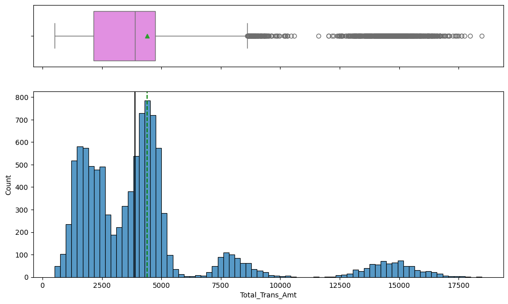

```python
histogram_boxplot(df, 'Total_Trans_Amt')
```

- The total transaction amount is right skewed.
- The median(50%) lies between 2500 and 5000.
- There are outliers where customers transactions exceed the median.

#### 2. What is the distribution of the level of education of customers?

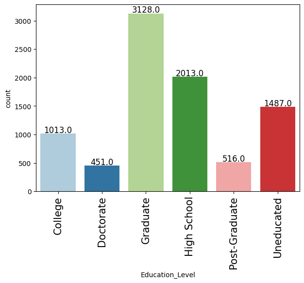

```python
labeled_barplot(df, 'Education_Level')
```

- The highest education level is the Graduates.
- Graduates means after undergraduate, right?
- The lowest would be doctorate.

#### 3. What is the distribution of the level of income of customers?

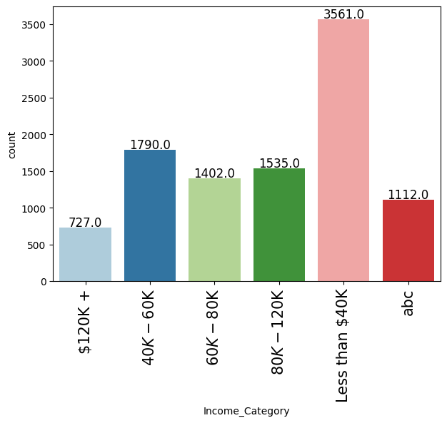

```python
labeled_barplot(df, 'Income_Category')
```

- The highest income category would be less than $40
- The lowest income category would be 120K+ dollars, which makes sense because not a lot of people would be making that much money.

#### 4. How does the change in transaction amount between Q4 and Q1 (total_ct_change_Q4_Q1) vary by the customer's account status (Attrition_Flag)?

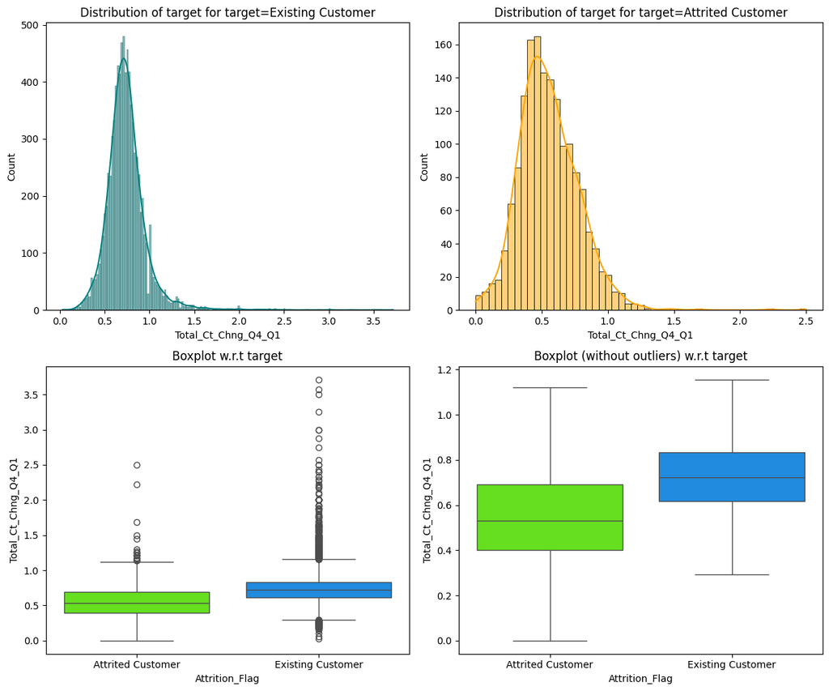

```python
distribution_plot_wrt_target(df, 'Total_Ct_Chng_Q4_Q1', 'Attrition_Flag')
```

#### 5.How does the number of months a customer was inactive in the last 12 months (Months_Inactive_12_mon) vary by the customer's account status (Attrition_Flag)?

```
Attrition_Flag          Attrited Customer  Existing Customer    All
Months_Inactive_12_mon
All                                  1627               8500  10127
3                                     826               3020   3846
2                                     505               2777   3282
4                                     130                305    435
1                                     100               2133   2233
5                                      32                146    178
6                                      19                105    124
0                                      15                 14     29
------------------------------------------------------------------------------------------------------------------------
```

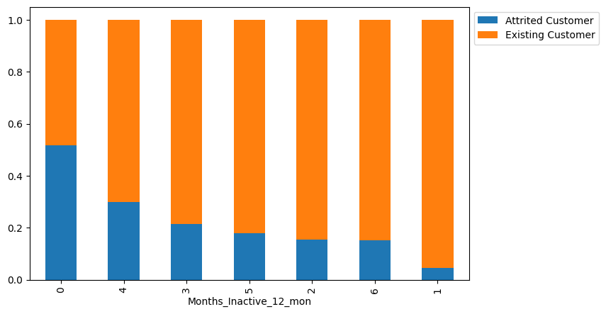

```python
stacked_barplot(df, 'Months_Inactive_12_mon', 'Attrition_Flag')
```

#### 6.What are the attributes that have a strong correlation with each other?

```python
#numerical features
num_features = df.select_dtypes(include=['float64', 'int64']).columns
corr = df[num_features].corr()
```

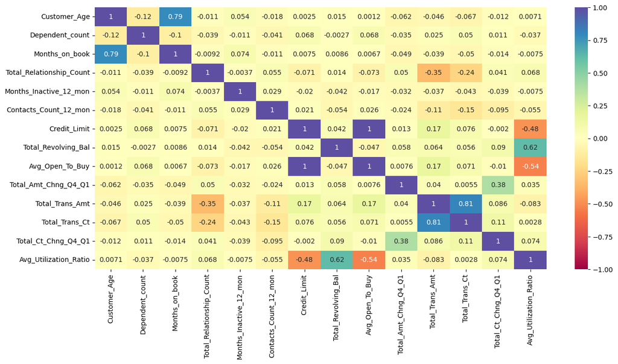

```python
plt.figure(figsize=(15,7))
sns.heatmap(corr,annot=True,vmin=-1,vmax=1,cmap="Spectral")
plt.show()
```

- Months_on_book and Customer_Age are strongly correlated with each other of 0.79.
- Avg_Open_To_Buy and Credit_Limit are strongly correlated with each other of 1.

## Data Pre-processing

#### Outlier Detection and Treatment

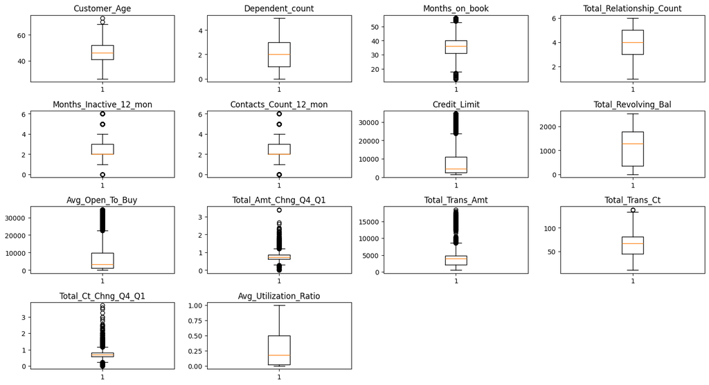

```python
numeric_columns = df.select_dtypes(include=np.number).columns.tolist()

plt.figure(figsize=(15, 12))

for i, variable in enumerate(numeric_columns):
    plt.subplot(6, 4, i + 1)
    plt.boxplot(df[variable], whis=1.5)
    plt.tight_layout()
    plt.title(variable)

plt.show()
```

- The outliers are present but they don't have to be treated.
- They are part of the data.

#### Data Preparation for model building

```python
df['Attrition_Flag'] = df['Attrition_Flag'].apply(lambda x : 1 if x=='Existing Customer' else 0)

X = df.drop(['Attrition_Flag'],axis=1)
y = df['Attrition_Flag']
```

```python
X
```

|  | Customer_Age | Gender | Dependent_count | Education_Level | Marital_Status | Income_Category | Card_Category | Months_on_book | Total_Relationship_Count | Months_Inactive_12_mon | Contacts_Count_12_mon | Credit_Limit | Total_Revolving_Bal | Avg_Open_To_Buy | Total_Amt_Chng_Q4_Q1 | Total_Trans_Amt | Total_Trans_Ct | Total_Ct_Chng_Q4_Q1 | Avg_Utilization_Ratio |
| --- | --- | --- | --- | --- | --- | --- | --- | --- | --- | --- | --- | --- | --- | --- | --- | --- | --- | --- | --- |
| 0 | 45 | M | 3 | High School | Married | $60K - $80K | Blue | 39 | 5 | 1 | 3 | 12691.0 | 777 | 11914.0 | 1.335 | 1144 | 42 | 1.625 | 0.061 |
| 1 | 49 | F | 5 | Graduate | Single | Less than $40K | Blue | 44 | 6 | 1 | 2 | 8256.0 | 864 | 7392.0 | 1.541 | 1291 | 33 | 3.714 | 0.105 |
| 2 | 51 | M | 3 | Graduate | Married | $80K - $120K | Blue | 36 | 4 | 1 | 0 | 3418.0 | 0 | 3418.0 | 2.594 | 1887 | 20 | 2.333 | 0.000 |
| 3 | 40 | F | 4 | High School | NaN | Less than $40K | Blue | 34 | 3 | 4 | 1 | 3313.0 | 2517 | 796.0 | 1.405 | 1171 | 20 | 2.333 | 0.760 |
| 4 | 40 | M | 3 | Uneducated | Married | $60K - $80K | Blue | 21 | 5 | 1 | 0 | 4716.0 | 0 | 4716.0 | 2.175 | 816 | 28 | 2.500 | 0.000 |
| ... | ... | ... | ... | ... | ... | ... | ... | ... | ... | ... | ... | ... | ... | ... | ... | ... | ... | ... | ... |
| 10122 | 50 | M | 2 | Graduate | Single | $40K - $60K | Blue | 40 | 3 | 2 | 3 | 4003.0 | 1851 | 2152.0 | 0.703 | 15476 | 117 | 0.857 | 0.462 |
| 10123 | 41 | M | 2 | NaN | Divorced | $40K - $60K | Blue | 25 | 4 | 2 | 3 | 4277.0 | 2186 | 2091.0 | 0.804 | 8764 | 69 | 0.683 | 0.511 |
| 10124 | 44 | F | 1 | High School | Married | Less than $40K | Blue | 36 | 5 | 3 | 4 | 5409.0 | 0 | 5409.0 | 0.819 | 10291 | 60 | 0.818 | 0.000 |
| 10125 | 30 | M | 2 | Graduate | NaN | $40K - $60K | Blue | 36 | 4 | 3 | 3 | 5281.0 | 0 | 5281.0 | 0.535 | 8395 | 62 | 0.722 | 0.000 |
| 10126 | 43 | F | 2 | Graduate | Married | Less than $40K | Silver | 25 | 6 | 2 | 4 | 10388.0 | 1961 | 8427.0 | 0.703 | 10294 | 61 | 0.649 | 0.189 |

10127 rows × 19 columns

#### Splitting Training, Validation, and Testing Datasets to prevent data leaks

```python
X_temp, X_test, y_temp, y_test = train_test_split(
    X,
    y,
    test_size=0.2,
    random_state=1,
    stratify=y
  )

X_train, X_val, y_train, y_val = train_test_split(
    X_temp,
    y_temp,
    test_size=0.25,
    random_state=1,
    stratify=y_temp
  )

print(X_train.shape, X_val.shape, X_test.shape)
```

```
(6075, 19) (2026, 19) (2026, 19)
```

#### Missing value imputation

##### Training Dataset

```python
X_train.isnull().sum()
```

|  | 0 |
| --- | --- |
| Customer_Age | 0 |
| Gender | 0 |
| Dependent_count | 0 |
| Education_Level | 897 |
| Marital_Status | 432 |
| Income_Category | 0 |
| Card_Category | 0 |
| Months_on_book | 0 |
| Total_Relationship_Count | 0 |
| Months_Inactive_12_mon | 0 |
| Contacts_Count_12_mon | 0 |
| Credit_Limit | 0 |
| Total_Revolving_Bal | 0 |
| Avg_Open_To_Buy | 0 |
| Total_Amt_Chng_Q4_Q1 | 0 |
| Total_Trans_Amt | 0 |
| Total_Trans_Ct | 0 |
| Total_Ct_Chng_Q4_Q1 | 0 |
| Avg_Utilization_Ratio | 0 |

**dtype:** int64

```python
# finds missing values in the Education_Level
X_train[X_train['Education_Level'].isnull()]
```

|  | Customer_Age | Gender | Dependent_count | Education_Level | Marital_Status | Income_Category | Card_Category | Months_on_book | Total_Relationship_Count | Months_Inactive_12_mon | Contacts_Count_12_mon | Credit_Limit | Total_Revolving_Bal | Avg_Open_To_Buy | Total_Amt_Chng_Q4_Q1 | Total_Trans_Amt | Total_Trans_Ct | Total_Ct_Chng_Q4_Q1 | Avg_Utilization_Ratio |
| --- | --- | --- | --- | --- | --- | --- | --- | --- | --- | --- | --- | --- | --- | --- | --- | --- | --- | --- | --- |
| 9501 | 47 | M | 2 | NaN | Divorced | $80K - $120K | Blue | 37 | 1 | 2 | 2 | 21714.0 | 1969 | 19745.0 | 0.944 | 13270 | 104 | 0.625 | 0.091 |
| 7947 | 47 | F | 2 | NaN | Married | Less than $40K | Blue | 42 | 1 | 3 | 3 | 1438.3 | 0 | 1438.3 | 0.677 | 4624 | 73 | 0.587 | 0.000 |
| 6053 | 48 | F | 4 | NaN | Married | Less than $40K | Blue | 41 | 3 | 3 | 3 | 2447.0 | 1267 | 1180.0 | 0.449 | 2132 | 37 | 0.370 | 0.518 |
| 3701 | 43 | M | 3 | NaN | NaN | $80K - $120K | Blue | 38 | 6 | 2 | 3 | 20348.0 | 1732 | 18616.0 | 0.674 | 1624 | 27 | 0.688 | 0.085 |
| 5743 | 49 | F | 1 | NaN | Married | Less than $40K | Blue | 40 | 5 | 1 | 3 | 2636.0 | 1840 | 796.0 | 0.844 | 4056 | 67 | 0.811 | 0.698 |
| ... | ... | ... | ... | ... | ... | ... | ... | ... | ... | ... | ... | ... | ... | ... | ... | ... | ... | ... | ... |
| 7256 | 54 | F | 2 | NaN | Single | Less than $40K | Blue | 46 | 3 | 2 | 3 | 4170.0 | 641 | 3529.0 | 0.815 | 3669 | 67 | 0.595 | 0.154 |
| 6770 | 52 | M | 1 | NaN | Divorced | $80K - $120K | Blue | 42 | 4 | 4 | 2 | 5763.0 | 0 | 5763.0 | 0.615 | 2310 | 48 | 0.714 | 0.000 |
| 3346 | 40 | M | 4 | NaN | Married | $60K - $80K | Blue | 36 | 3 | 2 | 3 | 22956.0 | 1407 | 21549.0 | 0.709 | 5554 | 64 | 0.600 | 0.061 |
| 7615 | 41 | F | 2 | NaN | NaN | Less than $40K | Blue | 34 | 6 | 3 | 3 | 2864.0 | 1928 | 936.0 | 0.769 | 4641 | 78 | 0.660 | 0.673 |
| 6230 | 49 | M | 3 | NaN | Married | $60K - $80K | Blue | 36 | 6 | 1 | 3 | 22651.0 | 1085 | 21566.0 | 0.810 | 3915 | 72 | 0.674 | 0.048 |

897 rows × 19 columns

```python
X_train['Education_Level'] = X_train['Education_Level'].cat.add_categories(['Unknown'])

X_train['Education_Level'] = X_train['Education_Level'].fillna('Unknown')
```

```python
# finds missing values in the Marital_Status
X_train[X_train['Marital_Status'].isnull()]
```

|  | Customer_Age | Gender | Dependent_count | Education_Level | Marital_Status | Income_Category | Card_Category | Months_on_book | Total_Relationship_Count | Months_Inactive_12_mon | Contacts_Count_12_mon | Credit_Limit | Total_Revolving_Bal | Avg_Open_To_Buy | Total_Amt_Chng_Q4_Q1 | Total_Trans_Amt | Total_Trans_Ct | Total_Ct_Chng_Q4_Q1 | Avg_Utilization_Ratio |
| --- | --- | --- | --- | --- | --- | --- | --- | --- | --- | --- | --- | --- | --- | --- | --- | --- | --- | --- | --- |
| 3594 | 47 | M | 4 | Uneducated | NaN | abc | Blue | 36 | 3 | 3 | 3 | 18873.0 | 0 | 18873.0 | 0.636 | 2021 | 38 | 0.520 | 0.000 |
| 3776 | 64 | F | 1 | College | NaN | Less than $40K | Blue | 56 | 3 | 1 | 2 | 6167.0 | 0 | 6167.0 | 0.422 | 1648 | 43 | 0.536 | 0.000 |
| 10064 | 43 | F | 4 | High School | NaN | Less than $40K | Silver | 31 | 6 | 2 | 2 | 13651.0 | 0 | 13651.0 | 1.046 | 9772 | 71 | 0.775 | 0.000 |
| 3701 | 43 | M | 3 | Unknown | NaN | $80K - $120K | Blue | 38 | 6 | 2 | 3 | 20348.0 | 1732 | 18616.0 | 0.674 | 1624 | 27 | 0.688 | 0.085 |
| 5411 | 44 | F | 3 | College | NaN | Less than $40K | Blue | 39 | 6 | 1 | 3 | 5024.0 | 2209 | 2815.0 | 0.660 | 4908 | 73 | 0.659 | 0.440 |
| ... | ... | ... | ... | ... | ... | ... | ... | ... | ... | ... | ... | ... | ... | ... | ... | ... | ... | ... | ... |
| 1045 | 42 | M | 4 | Graduate | NaN | $40K - $60K | Silver | 37 | 3 | 6 | 2 | 15871.0 | 2086 | 13785.0 | 0.745 | 1562 | 43 | 0.955 | 0.131 |
| 15 | 44 | M | 4 | Unknown | NaN | $80K - $120K | Blue | 37 | 5 | 1 | 2 | 4234.0 | 972 | 3262.0 | 1.707 | 1348 | 27 | 1.700 | 0.230 |
| 4374 | 42 | F | 2 | College | NaN | abc | Blue | 32 | 3 | 3 | 4 | 4035.0 | 1003 | 3032.0 | 0.583 | 4589 | 89 | 0.648 | 0.249 |
| 7615 | 41 | F | 2 | Unknown | NaN | Less than $40K | Blue | 34 | 6 | 3 | 3 | 2864.0 | 1928 | 936.0 | 0.769 | 4641 | 78 | 0.660 | 0.673 |
| 8438 | 46 | M | 2 | Graduate | NaN | $120K + | Blue | 34 | 1 | 3 | 2 | 24431.0 | 892 | 23539.0 | 0.417 | 3457 | 66 | 0.571 | 0.037 |

432 rows × 19 columns

```python
X_train['Marital_Status'] = X_train['Marital_Status'].cat.add_categories(['Unknown'])

X_train['Marital_Status'] = X_train['Marital_Status'].fillna('Unknown')
```

```python
X_train.isnull().sum()
```

|  | 0 |
| --- | --- |
| Customer_Age | 0 |
| Gender | 0 |
| Dependent_count | 0 |
| Education_Level | 0 |
| Marital_Status | 0 |
| Income_Category | 0 |
| Card_Category | 0 |
| Months_on_book | 0 |
| Total_Relationship_Count | 0 |
| Months_Inactive_12_mon | 0 |
| Contacts_Count_12_mon | 0 |
| Credit_Limit | 0 |
| Total_Revolving_Bal | 0 |
| Avg_Open_To_Buy | 0 |
| Total_Amt_Chng_Q4_Q1 | 0 |
| Total_Trans_Amt | 0 |
| Total_Trans_Ct | 0 |
| Total_Ct_Chng_Q4_Q1 | 0 |
| Avg_Utilization_Ratio | 0 |

**dtype:** int64

##### Validation Dataset

```python
X_val.isnull().sum()
```

|  | 0 |
| --- | --- |
| Customer_Age | 0 |
| Gender | 0 |
| Dependent_count | 0 |
| Education_Level | 308 |
| Marital_Status | 168 |
| Income_Category | 0 |
| Card_Category | 0 |
| Months_on_book | 0 |
| Total_Relationship_Count | 0 |
| Months_Inactive_12_mon | 0 |
| Contacts_Count_12_mon | 0 |
| Credit_Limit | 0 |
| Total_Revolving_Bal | 0 |
| Avg_Open_To_Buy | 0 |
| Total_Amt_Chng_Q4_Q1 | 0 |
| Total_Trans_Amt | 0 |
| Total_Trans_Ct | 0 |
| Total_Ct_Chng_Q4_Q1 | 0 |
| Avg_Utilization_Ratio | 0 |

**dtype:** int64

```python
# finds missing values in the Education_Level
X_val[X_val['Education_Level'].isnull()]
```

|  | Customer_Age | Gender | Dependent_count | Education_Level | Marital_Status | Income_Category | Card_Category | Months_on_book | Total_Relationship_Count | Months_Inactive_12_mon | Contacts_Count_12_mon | Credit_Limit | Total_Revolving_Bal | Avg_Open_To_Buy | Total_Amt_Chng_Q4_Q1 | Total_Trans_Amt | Total_Trans_Ct | Total_Ct_Chng_Q4_Q1 | Avg_Utilization_Ratio |
| --- | --- | --- | --- | --- | --- | --- | --- | --- | --- | --- | --- | --- | --- | --- | --- | --- | --- | --- | --- |
| 4923 | 47 | M | 4 | NaN | Divorced | $40K - $60K | Blue | 35 | 3 | 2 | 1 | 4907.0 | 773 | 4134.0 | 0.517 | 5088 | 71 | 0.651 | 0.158 |
| 2707 | 42 | M | 5 | NaN | Married | $60K - $80K | Blue | 35 | 6 | 3 | 2 | 13650.0 | 1253 | 12397.0 | 0.743 | 1703 | 53 | 0.710 | 0.092 |
| 5920 | 40 | M | 3 | NaN | Single | $80K - $120K | Blue | 23 | 6 | 2 | 2 | 12559.0 | 0 | 12559.0 | 0.715 | 4700 | 71 | 0.511 | 0.000 |
| 5688 | 44 | F | 3 | NaN | Married | abc | Blue | 25 | 6 | 1 | 3 | 19897.0 | 2232 | 17665.0 | 0.672 | 3979 | 63 | 0.500 | 0.112 |
| 8779 | 43 | F | 3 | NaN | Single | Less than $40K | Blue | 36 | 2 | 2 | 2 | 3849.0 | 1281 | 2568.0 | 0.777 | 7930 | 90 | 0.607 | 0.333 |
| ... | ... | ... | ... | ... | ... | ... | ... | ... | ... | ... | ... | ... | ... | ... | ... | ... | ... | ... | ... |
| 9837 | 53 | M | 2 | NaN | Single | $60K - $80K | Blue | 43 | 2 | 2 | 3 | 5905.0 | 0 | 5905.0 | 0.797 | 8883 | 83 | 0.729 | 0.000 |
| 4444 | 59 | F | 0 | NaN | Single | Less than $40K | Blue | 40 | 5 | 2 | 2 | 1845.0 | 1076 | 769.0 | 1.016 | 4319 | 76 | 0.551 | 0.583 |
| 7590 | 36 | F | 4 | NaN | Divorced | abc | Blue | 16 | 6 | 3 | 3 | 8513.0 | 0 | 8513.0 | 0.631 | 4162 | 70 | 1.000 | 0.000 |
| 3249 | 47 | M | 5 | NaN | Single | $120K + | Silver | 36 | 5 | 2 | 2 | 34516.0 | 1686 | 32830.0 | 0.937 | 4039 | 72 | 0.756 | 0.049 |
| 2808 | 64 | M | 0 | NaN | Married | Less than $40K | Blue | 51 | 3 | 3 | 4 | 2787.0 | 1201 | 1586.0 | 0.372 | 1662 | 39 | 0.625 | 0.431 |

308 rows × 19 columns

```python
X_val['Education_Level'] = X_val['Education_Level'].cat.add_categories(['Unknown'])

X_val['Education_Level'] = X_val['Education_Level'].fillna('Unknown')
```

```python
# finds missing values in the Marital_Status
X_val[X_val['Marital_Status'].isnull()]
```

|  | Customer_Age | Gender | Dependent_count | Education_Level | Marital_Status | Income_Category | Card_Category | Months_on_book | Total_Relationship_Count | Months_Inactive_12_mon | Contacts_Count_12_mon | Credit_Limit | Total_Revolving_Bal | Avg_Open_To_Buy | Total_Amt_Chng_Q4_Q1 | Total_Trans_Amt | Total_Trans_Ct | Total_Ct_Chng_Q4_Q1 | Avg_Utilization_Ratio |
| --- | --- | --- | --- | --- | --- | --- | --- | --- | --- | --- | --- | --- | --- | --- | --- | --- | --- | --- | --- |
| 2930 | 45 | F | 2 | Graduate | NaN | Less than $40K | Blue | 35 | 6 | 3 | 3 | 3240.0 | 2517 | 723.0 | 0.636 | 1904 | 41 | 0.519 | 0.777 |
| 6796 | 43 | M | 2 | Graduate | NaN | $60K - $80K | Blue | 25 | 5 | 3 | 1 | 7534.0 | 0 | 7534.0 | 0.587 | 4685 | 79 | 0.975 | 0.000 |
| 9315 | 61 | F | 1 | Graduate | NaN | $40K - $60K | Silver | 48 | 2 | 3 | 3 | 15698.0 | 2000 | 13698.0 | 0.749 | 12980 | 82 | 0.640 | 0.127 |
| 8750 | 41 | F | 3 | Unknown | NaN | $40K - $60K | Blue | 30 | 1 | 2 | 3 | 5357.0 | 1272 | 4085.0 | 0.708 | 7730 | 97 | 0.540 | 0.237 |
| 7767 | 57 | M | 1 | Graduate | NaN | $80K - $120K | Blue | 39 | 3 | 1 | 1 | 1438.3 | 641 | 797.3 | 0.660 | 5140 | 82 | 0.519 | 0.446 |
| ... | ... | ... | ... | ... | ... | ... | ... | ... | ... | ... | ... | ... | ... | ... | ... | ... | ... | ... | ... |
| 9431 | 37 | M | 1 | Doctorate | NaN | $60K - $80K | Blue | 36 | 1 | 3 | 1 | 7539.0 | 0 | 7539.0 | 1.023 | 15293 | 129 | 0.743 | 0.000 |
| 5930 | 52 | F | 4 | College | NaN | Less than $40K | Blue | 39 | 6 | 3 | 1 | 2035.0 | 1343 | 692.0 | 0.835 | 4643 | 86 | 0.686 | 0.660 |
| 7872 | 48 | F | 3 | High School | NaN | Less than $40K | Blue | 37 | 1 | 2 | 3 | 1438.3 | 0 | 1438.3 | 0.584 | 4236 | 83 | 0.844 | 0.000 |
| 5490 | 44 | F | 2 | Graduate | NaN | Less than $40K | Blue | 34 | 3 | 2 | 2 | 2561.0 | 1491 | 1070.0 | 0.733 | 4869 | 70 | 0.522 | 0.582 |
| 8597 | 42 | M | 1 | Graduate | NaN | $80K - $120K | Blue | 36 | 2 | 1 | 2 | 4765.0 | 1516 | 3249.0 | 0.709 | 7380 | 76 | 0.689 | 0.318 |

168 rows × 19 columns

```python
X_val['Marital_Status'] = X_val['Marital_Status'].cat.add_categories(['Unknown'])

X_val['Marital_Status'] = X_val['Marital_Status'].fillna('Unknown')
```

```python
X_val.isnull().sum()
```

|  | 0 |
| --- | --- |
| Customer_Age | 0 |
| Gender | 0 |
| Dependent_count | 0 |
| Education_Level | 0 |
| Marital_Status | 0 |
| Income_Category | 0 |
| Card_Category | 0 |
| Months_on_book | 0 |
| Total_Relationship_Count | 0 |
| Months_Inactive_12_mon | 0 |
| Contacts_Count_12_mon | 0 |
| Credit_Limit | 0 |
| Total_Revolving_Bal | 0 |
| Avg_Open_To_Buy | 0 |
| Total_Amt_Chng_Q4_Q1 | 0 |
| Total_Trans_Amt | 0 |
| Total_Trans_Ct | 0 |
| Total_Ct_Chng_Q4_Q1 | 0 |
| Avg_Utilization_Ratio | 0 |

**dtype:** int64

##### Testing Dataset

```python
X_test.isnull().sum()
```

|  | 0 |
| --- | --- |
| Customer_Age | 0 |
| Gender | 0 |
| Dependent_count | 0 |
| Education_Level | 314 |
| Marital_Status | 149 |
| Income_Category | 0 |
| Card_Category | 0 |
| Months_on_book | 0 |
| Total_Relationship_Count | 0 |
| Months_Inactive_12_mon | 0 |
| Contacts_Count_12_mon | 0 |
| Credit_Limit | 0 |
| Total_Revolving_Bal | 0 |
| Avg_Open_To_Buy | 0 |
| Total_Amt_Chng_Q4_Q1 | 0 |
| Total_Trans_Amt | 0 |
| Total_Trans_Ct | 0 |
| Total_Ct_Chng_Q4_Q1 | 0 |
| Avg_Utilization_Ratio | 0 |

**dtype:** int64

```python
# finds missing values in the Education_Level
X_test[X_test['Education_Level'].isnull()]
```

|  | Customer_Age | Gender | Dependent_count | Education_Level | Marital_Status | Income_Category | Card_Category | Months_on_book | Total_Relationship_Count | Months_Inactive_12_mon | Contacts_Count_12_mon | Credit_Limit | Total_Revolving_Bal | Avg_Open_To_Buy | Total_Amt_Chng_Q4_Q1 | Total_Trans_Amt | Total_Trans_Ct | Total_Ct_Chng_Q4_Q1 | Avg_Utilization_Ratio |
| --- | --- | --- | --- | --- | --- | --- | --- | --- | --- | --- | --- | --- | --- | --- | --- | --- | --- | --- | --- |
| 2901 | 49 | M | 2 | NaN | Single | $40K - $60K | Blue | 37 | 5 | 1 | 3 | 2993.0 | 1265 | 1728.0 | 0.579 | 4089 | 72 | 0.674 | 0.423 |
| 5020 | 50 | M | 2 | NaN | Married | $120K + | Gold | 35 | 4 | 5 | 3 | 34516.0 | 668 | 33848.0 | 0.894 | 3931 | 77 | 0.791 | 0.019 |
| 4468 | 44 | M | 3 | NaN | Married | $40K - $60K | Blue | 36 | 4 | 2 | 1 | 2534.0 | 1706 | 828.0 | 0.793 | 3965 | 57 | 1.111 | 0.673 |
| 7202 | 49 | F | 2 | NaN | Single | $40K - $60K | Blue | 44 | 6 | 1 | 3 | 2147.0 | 1402 | 745.0 | 0.612 | 4240 | 69 | 0.683 | 0.653 |
| 3661 | 55 | M | 1 | NaN | NaN | $120K + | Blue | 46 | 4 | 1 | 2 | 19849.0 | 2205 | 17644.0 | 0.796 | 3657 | 66 | 0.737 | 0.111 |
| ... | ... | ... | ... | ... | ... | ... | ... | ... | ... | ... | ... | ... | ... | ... | ... | ... | ... | ... | ... |
| 2946 | 62 | M | 0 | NaN | Married | $40K - $60K | Blue | 48 | 4 | 1 | 2 | 1438.3 | 0 | 1438.3 | 0.425 | 1406 | 27 | 0.500 | 0.000 |
| 1401 | 49 | M | 1 | NaN | Single | $80K - $120K | Blue | 31 | 6 | 1 | 4 | 5898.0 | 1348 | 4550.0 | 0.640 | 1002 | 21 | 1.333 | 0.229 |
| 962 | 60 | M | 1 | NaN | Single | Less than $40K | Blue | 52 | 5 | 3 | 2 | 2486.0 | 1464 | 1022.0 | 0.731 | 1378 | 27 | 0.421 | 0.589 |
| 1201 | 57 | F | 1 | NaN | Married | Less than $40K | Blue | 47 | 4 | 1 | 3 | 3416.0 | 2468 | 948.0 | 0.598 | 1536 | 42 | 0.556 | 0.722 |
| 3610 | 40 | M | 2 | NaN | Married | $60K - $80K | Blue | 34 | 6 | 3 | 0 | 3269.0 | 1601 | 1668.0 | 1.168 | 3966 | 74 | 0.947 | 0.490 |

314 rows × 19 columns

```python
X_test['Education_Level'] = X_test['Education_Level'].cat.add_categories(['Unknown'])

X_test['Education_Level'] = X_test['Education_Level'].fillna('Unknown')
```

```python
# finds missing values in the Marital_Status
X_test[X_test['Marital_Status'].isnull()]
```

|  | Customer_Age | Gender | Dependent_count | Education_Level | Marital_Status | Income_Category | Card_Category | Months_on_book | Total_Relationship_Count | Months_Inactive_12_mon | Contacts_Count_12_mon | Credit_Limit | Total_Revolving_Bal | Avg_Open_To_Buy | Total_Amt_Chng_Q4_Q1 | Total_Trans_Amt | Total_Trans_Ct | Total_Ct_Chng_Q4_Q1 | Avg_Utilization_Ratio |
| --- | --- | --- | --- | --- | --- | --- | --- | --- | --- | --- | --- | --- | --- | --- | --- | --- | --- | --- | --- |
| 9295 | 27 | M | 0 | College | NaN | $80K - $120K | Silver | 19 | 1 | 1 | 3 | 34516.0 | 1131 | 33385.0 | 0.715 | 14716 | 112 | 0.750 | 0.033 |
| 3661 | 55 | M | 1 | Unknown | NaN | $120K + | Blue | 46 | 4 | 1 | 2 | 19849.0 | 2205 | 17644.0 | 0.796 | 3657 | 66 | 0.737 | 0.111 |
| 7212 | 45 | F | 5 | Post-Graduate | NaN | Less than $40K | Blue | 36 | 5 | 2 | 3 | 2658.0 | 694 | 1964.0 | 0.722 | 4774 | 92 | 0.769 | 0.261 |
| 2888 | 44 | M | 4 | Graduate | NaN | $80K - $120K | Blue | 34 | 4 | 3 | 2 | 26856.0 | 0 | 26856.0 | 0.581 | 4222 | 75 | 0.471 | 0.000 |
| 6169 | 44 | M | 3 | College | NaN | $60K - $80K | Blue | 33 | 6 | 3 | 2 | 15468.0 | 1187 | 14281.0 | 0.930 | 4484 | 81 | 0.841 | 0.077 |
| ... | ... | ... | ... | ... | ... | ... | ... | ... | ... | ... | ... | ... | ... | ... | ... | ... | ... | ... | ... |
| 2382 | 49 | F | 2 | High School | NaN | $40K - $60K | Blue | 38 | 4 | 1 | 2 | 2497.0 | 1674 | 823.0 | 0.701 | 2922 | 53 | 0.963 | 0.670 |
| 4453 | 52 | F | 3 | Graduate | NaN | $40K - $60K | Blue | 45 | 5 | 2 | 0 | 10859.0 | 1710 | 9149.0 | 0.974 | 3987 | 64 | 0.829 | 0.157 |
| 7940 | 49 | F | 5 | Graduate | NaN | Less than $40K | Blue | 36 | 1 | 3 | 2 | 3272.0 | 2085 | 1187.0 | 0.417 | 4444 | 83 | 0.627 | 0.637 |
| 4392 | 43 | F | 4 | High School | NaN | Less than $40K | Blue | 36 | 5 | 2 | 4 | 2459.0 | 1127 | 1332.0 | 0.765 | 4343 | 83 | 0.886 | 0.458 |
| 5037 | 39 | M | 1 | High School | NaN | $40K - $60K | Blue | 28 | 5 | 2 | 4 | 2222.0 | 0 | 2222.0 | 0.843 | 4792 | 62 | 0.722 | 0.000 |

149 rows × 19 columns

```python
X_test['Marital_Status'] = X_test['Marital_Status'].cat.add_categories(['Unknown'])

X_test['Marital_Status'] = X_test['Marital_Status'].fillna('Unknown')
```

```python
X_test.isnull().sum()
```

|  | 0 |
| --- | --- |
| Customer_Age | 0 |
| Gender | 0 |
| Dependent_count | 0 |
| Education_Level | 0 |
| Marital_Status | 0 |
| Income_Category | 0 |
| Card_Category | 0 |
| Months_on_book | 0 |
| Total_Relationship_Count | 0 |
| Months_Inactive_12_mon | 0 |
| Contacts_Count_12_mon | 0 |
| Credit_Limit | 0 |
| Total_Revolving_Bal | 0 |
| Avg_Open_To_Buy | 0 |
| Total_Amt_Chng_Q4_Q1 | 0 |
| Total_Trans_Amt | 0 |
| Total_Trans_Ct | 0 |
| Total_Ct_Chng_Q4_Q1 | 0 |
| Avg_Utilization_Ratio | 0 |

**dtype:** int64

##### get_dummies conversion

```python
X_train = pd.get_dummies(X_train, drop_first=True)

X_val = pd.get_dummies(X_val, drop_first=True)

X_test = pd.get_dummies(X_test, drop_first=True)
```

- The validation and the test dataset have the same shape

```python
y.value_counts(1)
```

| Attrition_Flag | proportion |
| --- | --- |
| 1 | 0.83934 |
| 0 | 0.16066 |

**dtype:** float64

```python
y_train.value_counts(1)
```

| Attrition_Flag | proportion |
| --- | --- |
| 1 | 0.839342 |
| 0 | 0.160658 |

**dtype:** float64

```python
y_val.value_counts(1)
```

| Attrition_Flag | proportion |
| --- | --- |
| 1 | 0.839092 |
| 0 | 0.160908 |

**dtype:** float64

## Model Building

### Model evaluation criterion

**Let's define a function to output different metrics (including recall) on the train and test set and a function to show confusion matrix so that we do not have to use the same code repetitively while evaluating models.**

```python
# defining a function to compute different metrics to check performance of a classification model built using sklearn
def model_performance_classification_sklearn(model, predictors, target):
    """
    Function to compute different metrics to check classification model performance

    model: classifier
    predictors: independent variables
    target: dependent variable
    """

    # predicting using the independent variables
    pred = model.predict(predictors)

    acc = accuracy_score(target, pred)  # to compute Accuracy
    recall = recall_score(target, pred)  # to compute Recall
    precision = precision_score(target, pred)  # to compute Precision
    f1 = f1_score(target, pred)  # to compute F1-score

    # creating a dataframe of metrics
    df_perf = pd.DataFrame(
        {
            "Accuracy": acc,
            "Recall": recall,
            "Precision": precision,
            "F1": f1

        },
        index=[0],
    )

    return df_perf
```

```python
def confusion_matrix_sklearn(model, predictors, target):
    """
    To plot the confusion_matrix with percentages

    model: classifier
    predictors: independent variables
    target: dependent variable
    """
    y_pred = model.predict(predictors)
    cm = confusion_matrix(target, y_pred)
    labels = np.asarray(
        [
            ["{0:0.0f}".format(item) + "\n{0:.2%}".format(item / cm.flatten().sum())]
            for item in cm.flatten()
        ]
    ).reshape(2, 2)

    plt.figure(figsize=(6, 4))
    sns.heatmap(cm, annot=labels, fmt="")
    plt.ylabel("True label")
    plt.xlabel("Predicted label")
```

### Model Building with original data

Sample code for model building with original data

```python
models = []  # Empty list to store all the models

# Appending models into the list
models.append(("Bagging", BaggingClassifier(random_state=1)))
models.append(("Random forest", RandomForestClassifier(random_state=1)))
models.append(("Decision tree", DecisionTreeClassifier(random_state=1)))
models.append(("AdaBoost", AdaBoostClassifier(random_state=1)))
models.append(("Gradient Boosting", GradientBoostingClassifier(random_state=1)))
models.append(("XGBoost", XGBClassifier(random_state=1)))
models.append(("Logistic Regression", LogisticRegression(max_iter=200, solver='liblinear', random_state=1)))
## Complete the code to append remaining 3 or more in the list models

print("\n" "Training Recall Performance:" "\n")
for name, model in models:
    model.fit(X_train, y_train)
    scores = recall_score(y_train, model.predict(X_train))
    print(f"{name}: {scores}".format(name, scores))

print("\n" "Validation Recall Performance:" "\n")

for name, model in models:
    model.fit(X_train, y_train)
    scores_val = recall_score(y_val, model.predict(X_val))
    print(f"{name}: {scores_val}".format(name, scores_val))
```

```
Training Recall Performance:

Bagging: 0.9976465973720338
Random forest: 1.0
Decision tree: 1.0
AdaBoost: 0.9839184153755638
Gradient Boosting: 0.9927436752304374
XGBoost: 1.0
Logistic Regression: 0.9697979996077662

Validation Recall Performance:

Bagging: 0.9764705882352941
Random forest: 0.9858823529411764
Decision tree: 0.9611764705882353
AdaBoost: 0.9852941176470589
Gradient Boosting: 0.9894117647058823
XGBoost: 0.99
Logistic Regression: 0.97
```

### Model Building Tuned with original data

##### Bagging Classifier Tuned

```python
bagging_estimator_tuned = BaggingClassifier(random_state=1)

parameters = {
    'max_samples': [0.7,0.8,0.9,1],
    'max_features': [0.7,0.8,0.9,1],
    'n_estimators' : [5,7,15,51,101],
}

acc_scorer = metrics.make_scorer(metrics.recall_score)

grid_obj = GridSearchCV(estimator=bagging_estimator_tuned, param_grid=parameters, scoring=acc_scorer, cv=5)
grid_obj = grid_obj.fit(X_train, y_train)

bagging_estimator_tuned = grid_obj.best_estimator_

bagging_estimator_tuned.fit(X_train, y_train)
```

```
BaggingClassifier(max_features=0.7, max_samples=1, n_estimators=5,
                  random_state=1)
```

```python
print("Bagging Classifier Tuned Train Metrics:")
df_bagging_estimator_tuned_train = model_performance_classification_sklearn(bagging_estimator_tuned, X_train, y_train)
df_bagging_estimator_tuned_train
```

```
Bagging Classifier Tuned Train Metrics:
```

|  | Accuracy | Recall | Precision | F1 |
| --- | --- | --- | --- | --- |
| 0 | 0.839342 | 1.0 | 0.839342 | 0.912654 |

```python
print("Bagging Classifier Tuned Validation Metrics:")
df_bagging_estimator_tuned_validation = model_performance_classification_sklearn(bagging_estimator_tuned, X_val, y_val)
df_bagging_estimator_tuned_validation
```

```
Bagging Classifier Tuned Validation Metrics:
```

|  | Accuracy | Recall | Precision | F1 |
| --- | --- | --- | --- | --- |
| 0 | 0.839092 | 1.0 | 0.839092 | 0.912507 |

- After hypertuning the bagging classifier with the base estimator as decision tree the performance of the recall has reached exactly 1 for training and validation set.
- The accuracy, precision, and F1 score has slightly decreased for the validation score.
- I tuned the max samples, max features, and number of estimators and applied a grid search cross validation for hyperparameter tuning.

##### Bagging Classifier Tuned: base_estimator=LogisticRegression

```python
bagging_estimator_tuned_logistic_regression = BaggingClassifier(
    estimator=LogisticRegression(max_iter=1000, solver='liblinear', random_state=1),
    random_state=1
)
bagging_estimator_tuned_logistic_regression.fit(X_train, y_train)
```

```
BaggingClassifier(estimator=LogisticRegression(max_iter=1000, random_state=1,
                                               solver='liblinear'),
                  random_state=1)
```

```python
print("Bagging Classifier Tuned (base_estimator=LogisticRegression) Train Metrics:")
df_bagging_estimator_tuned_logistic_regression_train = model_performance_classification_sklearn(bagging_estimator_tuned_logistic_regression, X_train, y_train)
df_bagging_estimator_tuned_logistic_regression_train
```

```
Bagging Classifier Tuned (base_estimator=LogisticRegression) Train Metrics:
```

|  | Accuracy | Recall | Precision | F1 |
| --- | --- | --- | --- | --- |
| 0 | 0.894321 | 0.967445 | 0.911999 | 0.938904 |

```python
print("Bagging Classifier Tuned (base_estimator=LogisticRegression) Validation Metrics:")
df_bagging_estimator_tuned_logistic_regression_validation = model_performance_classification_sklearn(bagging_estimator_tuned_logistic_regression, X_val, y_val)
df_bagging_estimator_tuned_logistic_regression_validation
```

```
Bagging Classifier Tuned (base_estimator=LogisticRegression) Validation Metrics:
```

|  | Accuracy | Recall | Precision | F1 |
| --- | --- | --- | --- | --- |
| 0 | 0.883514 | 0.968235 | 0.900438 | 0.933107 |

- For the base estimator I used Logistic Regression instead of the default.
- I set the maximum iterations to 1000.
- The reacall has great performance but there is only a 0.1% increase for the validation set.
- The training set recall is 96.74% and the validation set recall is 96.82%.
- Even though there is a difference between the training and validation recall I think it is still a good classifier.
- The accuracy, precision, and F1 score is slightly better for the training set.

##### Random Forest Classifier Tuned (without class_weights)

```python
random_forest_estimator_tuned = RandomForestClassifier(random_state=1)

parameters = {
    'max_samples': np.arange(0.3, 0.7, 0.1),
    'max_features': np.arange(0.2, 0.7, 0.1),
    'n_estimators' : [5,7,15,51,101],
    'min_samples_leaf': np.arange(5, 10),
}

acc_scorer = metrics.make_scorer(metrics.recall_score)

grid_obj = GridSearchCV(estimator=random_forest_estimator_tuned, param_grid=parameters, scoring=acc_scorer, cv=5)
grid_obj = grid_obj.fit(X_train, y_train)

random_forest_estimator_tuned = grid_obj.best_estimator_

random_forest_estimator_tuned.fit(X_train, y_train)
```

```
RandomForestClassifier(max_features=0.2, max_samples=0.4, min_samples_leaf=9,
                       n_estimators=15, random_state=1)
```

```python
print("Random Forest Classifier Tuned (without class_weights) Train Metrics:")
df_random_forest_estimator_tuned_train = model_performance_classification_sklearn(random_forest_estimator_tuned, X_train, y_train)
df_random_forest_estimator_tuned_train
```

```
Random Forest Classifier Tuned (without class_weights) Train Metrics:
```

|  | Accuracy | Recall | Precision | F1 |
| --- | --- | --- | --- | --- |
| 0 | 0.946008 | 0.988429 | 0.949331 | 0.968486 |

```python
print("Random Forest Classifier Tuned (without class_weights) Validation Metrics:")
df_random_forest_estimator_tuned_validation = model_performance_classification_sklearn(random_forest_estimator_tuned, X_val, y_val)
df_random_forest_estimator_tuned_validation
```

```
Random Forest Classifier Tuned (without class_weights) Validation Metrics:
```

|  | Accuracy | Recall | Precision | F1 |
| --- | --- | --- | --- | --- |
| 0 | 0.923988 | 0.982353 | 0.930881 | 0.955924 |

- The recall is slightly low for the validation set but the accuracy, precision, and F1 score is slightly higher in the training set.
- This is tuned without class weights.

##### Random Forest Classifier Weighted Tuned (with class_weights)

```python
random_forest_estimator_tuned_weighted = RandomForestClassifier(random_state=1)

parameters = {
    'max_samples': np.arange(0.3, 0.8, 0.1),
    'max_features': np.arange(0.2, 0.8, 0.1),
    'n_estimators' : [15,51,101],
    'min_samples_leaf': np.arange(5, 11),
    'class_weight': [{0: 0.7, 1: 0.3}],
}

acc_scorer = metrics.make_scorer(metrics.recall_score)

grid_obj = GridSearchCV(estimator=random_forest_estimator_tuned_weighted, param_grid=parameters, scoring=acc_scorer, cv=5)
grid_obj = grid_obj.fit(X_train, y_train)

random_forest_estimator_tuned_weighted = grid_obj.best_estimator_

random_forest_estimator_tuned_weighted.fit(X_train, y_train)
```

```
RandomForestClassifier(class_weight={0: 0.7, 1: 0.3}, max_features=0.2,
                       max_samples=0.6000000000000001, min_samples_leaf=5,
                       n_estimators=51, random_state=1)
```

```python
print("Random Forest Classifier Weighted Tuned (with class_weights) Train Metrics:")
df_random_forest_estimator_tuned_weighted_train = model_performance_classification_sklearn(random_forest_estimator_tuned_weighted, X_train, y_train)
df_random_forest_estimator_tuned_weighted_train
```

```
Random Forest Classifier Weighted Tuned (with class_weights) Train Metrics:
```

|  | Accuracy | Recall | Precision | F1 |
| --- | --- | --- | --- | --- |
| 0 | 0.973498 | 0.983134 | 0.985259 | 0.984196 |

```python
print("Random Forest Classifier Weighted Tuned (with class_weights) Validation Metrics:")
df_random_forest_estimator_tuned_weighted_validation = model_performance_classification_sklearn(random_forest_estimator_tuned_weighted, X_val, y_val)
df_random_forest_estimator_tuned_weighted_validation
```

```
Random Forest Classifier Weighted Tuned (with class_weights) Validation Metrics:
```

|  | Accuracy | Recall | Precision | F1 |
| --- | --- | --- | --- | --- |
| 0 | 0.943731 | 0.977059 | 0.956797 | 0.966822 |

##### AdaBoost Classifier Tuned

```python
ada_boost_estimator_tuned = AdaBoostClassifier(random_state=1)

parameters = {
    'n_estimators': np.arange(10,90,10),
    'learning_rate': [1, 0.1, 0.5, 0.01],
}

acc_scorer = metrics.make_scorer(metrics.recall_score)

grid_obj = GridSearchCV(estimator=ada_boost_estimator_tuned, param_grid=parameters, scoring=acc_scorer, cv=5)
grid_obj = grid_obj.fit(X_train, y_train)

ada_boost_estimator_tuned = grid_obj.best_estimator_

ada_boost_estimator_tuned.fit(X_train, y_train)
```

```
AdaBoostClassifier(learning_rate=0.1, n_estimators=10, random_state=1)
```

```python
print("Ada Boost Classifier Tuned Train Metrics:")
df_ada_boost_estimator_tuned_train = model_performance_classification_sklearn(ada_boost_estimator_tuned, X_train, y_train)
df_ada_boost_estimator_tuned_train
```

```
Ada Boost Classifier Tuned Train Metrics:
```

|  | Accuracy | Recall | Precision | F1 |
| --- | --- | --- | --- | --- |
| 0 | 0.839342 | 1.0 | 0.839342 | 0.912654 |

```python
print("Ada Boost Classifier Tuned Validation Metrics:")
df_ada_boost_estimator_tuned_validation = model_performance_classification_sklearn(ada_boost_estimator_tuned, X_val, y_val)
df_ada_boost_estimator_tuned_validation
```

```
Ada Boost Classifier Tuned Validation Metrics:
```

|  | Accuracy | Recall | Precision | F1 |
| --- | --- | --- | --- | --- |
| 0 | 0.839092 | 1.0 | 0.839092 | 0.912507 |

- The recall is the same for training and testing sets.
- The accuracy has decreased compared to other classifiers.

##### Gradient Boosting Classifier Tuned

```python
gradient_boosting_estimator_tuned = GradientBoostingClassifier(random_state=1)

parameters = {
    'n_estimators': np.arange(10,90,10),
    'max_features':[0.7,0.8,0.9],
    'max_depth':[3,5,7]
}

acc_scorer = metrics.make_scorer(metrics.recall_score)

grid_obj = GridSearchCV(estimator=gradient_boosting_estimator_tuned, param_grid=parameters, scoring=acc_scorer, cv=4)
grid_obj = grid_obj.fit(X_train, y_train)

gradient_boosting_estimator_tuned = grid_obj.best_estimator_

gradient_boosting_estimator_tuned.fit(X_train, y_train)
```

```
GradientBoostingClassifier(max_features=0.8, n_estimators=10, random_state=1)
```

```python
print("Gradient Boosting Classifier Tuned Train Metrics:")
df_gradient_boosting_estimator_tuned_train = model_performance_classification_sklearn(gradient_boosting_estimator_tuned, X_train, y_train)
df_gradient_boosting_estimator_tuned_train
```

```
Gradient Boosting Classifier Tuned Train Metrics:
```

|  | Accuracy | Recall | Precision | F1 |
| --- | --- | --- | --- | --- |
| 0 | 0.914568 | 0.994313 | 0.911871 | 0.951309 |

```python
print("Gradient Boosting Classifier Tuned Validation Metrics:")
df_gradient_boosting_estimator_tuned_validation = model_performance_classification_sklearn(gradient_boosting_estimator_tuned, X_val, y_val)
df_gradient_boosting_estimator_tuned_validation
```

```
Gradient Boosting Classifier Tuned Validation Metrics:
```

|  | Accuracy | Recall | Precision | F1 |
| --- | --- | --- | --- | --- |
| 0 | 0.901777 | 0.992353 | 0.900694 | 0.944305 |

- The validation set slightly overfits to the data.
- The training set recall is 99.43% and the validation set recall is 99.23%.

### Model Building with Oversampled data

```python
# Synthetic Minority Over Sampling Technique
sm = SMOTE(sampling_strategy=1, k_neighbors=5, random_state=1)
X_train_over, y_train_over = sm.fit_resample(X_train, y_train)
```

##### Bagging Classifier with oversampled data

```python
bagging_estimator_tuned_oversampled = BaggingClassifier(random_state=1)

bagging_estimator_tuned_oversampled.fit(X_train_over, y_train_over)
```

```
BaggingClassifier(random_state=1)
```

```python
print("Bagging Classifier Tuned Oversampled Train Metrics:")
df_bagging_estimator_tuned_oversampled_train = model_performance_classification_sklearn(bagging_estimator_tuned_oversampled, X_train_over, y_train_over)
df_bagging_estimator_tuned_oversampled_train
```

```
Bagging Classifier Tuned Oversampled Train Metrics:
```

|  | Accuracy | Recall | Precision | F1 |
| --- | --- | --- | --- | --- |
| 0 | 0.997352 | 0.995489 | 0.999213 | 0.997347 |

```python
print("Bagging Classifier Tuned Oversampled Validation Metrics:")
df_bagging_estimator_tuned_oversampled_validation = model_performance_classification_sklearn(bagging_estimator_tuned_oversampled, X_val, y_val)
df_bagging_estimator_tuned_oversampled_validation
```

```
Bagging Classifier Tuned Oversampled Validation Metrics:
```

|  | Accuracy | Recall | Precision | F1 |
| --- | --- | --- | --- | --- |
| 0 | 0.942251 | 0.955294 | 0.975375 | 0.96523 |

- The training set has a recall of 99.54% and the validation set has 95.52%.
- The validation set slightly over fits to the data.

##### Random Forest Classifier with oversampled data

```python
random_forest_estimator_tuned_oversampled = RandomForestClassifier(random_state=1)

random_forest_estimator_tuned_oversampled.fit(X_train_over, y_train_over)
```

```
RandomForestClassifier(random_state=1)
```

```python
print("Random Forest Classifier Tuned Oversampled Train Metrics:")
df_random_forest_estimator_tuned_oversampled_train = model_performance_classification_sklearn(random_forest_estimator_tuned_oversampled, X_train_over, y_train_over)
df_random_forest_estimator_tuned_oversampled_train
```

```
Random Forest Classifier Tuned Oversampled Train Metrics:
```

|  | Accuracy | Recall | Precision | F1 |
| --- | --- | --- | --- | --- |
| 0 | 1.0 | 1.0 | 1.0 | 1.0 |

```python
print("Random Forest Classifier Tuned Oversampled Validation Metrics:")
df_random_forest_estimator_tuned_oversampled_validation = model_performance_classification_sklearn(random_forest_estimator_tuned_oversampled, X_val, y_val)
df_random_forest_estimator_tuned_oversampled_validation
```

```
Random Forest Classifier Tuned Oversampled Validation Metrics:
```

|  | Accuracy | Recall | Precision | F1 |
| --- | --- | --- | --- | --- |
| 0 | 0.948174 | 0.972941 | 0.965558 | 0.969235 |

- The training recall and other metrics have 1, but the validation set has 97.29%.
- The validation set overfits to the data.

##### Ada Boost Classifier with oversampled data

```python
ada_boost_estimator_tuned_oversampled = AdaBoostClassifier(random_state=1)

ada_boost_estimator_tuned_oversampled.fit(X_train_over, y_train_over)
```

```
AdaBoostClassifier(random_state=1)
```

```python
print("Ada Boost Classifier Tuned Oversampled Train Metrics:")
df_ada_boost_estimator_tuned_oversampled_train = model_performance_classification_sklearn(ada_boost_estimator_tuned_oversampled, X_train_over, y_train_over)
df_ada_boost_estimator_tuned_oversampled_train
```

```
Ada Boost Classifier Tuned Oversampled Train Metrics:
```

|  | Accuracy | Recall | Precision | F1 |
| --- | --- | --- | --- | --- |
| 0 | 0.94999 | 0.949206 | 0.950697 | 0.949951 |

```python
print("Ada Boost Classifier Tuned Oversampled Validation Metrics:")
df_ada_boost_estimator_tuned_oversampled_validation = model_performance_classification_sklearn(ada_boost_estimator_tuned_oversampled, X_val, y_val)
df_ada_boost_estimator_tuned_oversampled_validation
```

```
Ada Boost Classifier Tuned Oversampled Validation Metrics:
```

|  | Accuracy | Recall | Precision | F1 |
| --- | --- | --- | --- | --- |
| 0 | 0.932873 | 0.948824 | 0.970517 | 0.959548 |

##### Gradient Boost Classifier with oversampled data

```python
gradient_boosting_estimator_tuned_oversampled = GradientBoostingClassifier(random_state=1)

gradient_boosting_estimator_tuned_oversampled.fit(X_train_over, y_train_over)
```

```
GradientBoostingClassifier(random_state=1)
```

```python
print("Gradient Boost Classifier Tuned Oversampled Train Metrics:")
df_gradient_boosting_estimator_tuned_oversampled_train = model_performance_classification_sklearn(gradient_boosting_estimator_tuned_oversampled, X_train_over, y_train_over)
df_gradient_boosting_estimator_tuned_oversampled_train
```

```
Gradient Boost Classifier Tuned Oversampled Train Metrics:
```

|  | Accuracy | Recall | Precision | F1 |
| --- | --- | --- | --- | --- |
| 0 | 0.978329 | 0.975485 | 0.981065 | 0.978267 |

```python
print("Ada Boost Classifier Tuned Oversampled Validation Metrics:")
df_gradient_boosting_estimator_tuned_oversampled_validation = model_performance_classification_sklearn(gradient_boosting_estimator_tuned_oversampled, X_val, y_val)
df_gradient_boosting_estimator_tuned_oversampled_validation
```

```
Ada Boost Classifier Tuned Oversampled Validation Metrics:
```

|  | Accuracy | Recall | Precision | F1 |
| --- | --- | --- | --- | --- |
| 0 | 0.959033 | 0.974706 | 0.976429 | 0.975567 |

##### XG Boosting Classifier with oversampled data

```python
xg_boost_estimator_tuned_oversampled = XGBClassifier(random_state=1)

xg_boost_estimator_tuned_oversampled.fit(X_train_over, y_train_over)
```

[output not shown]

[output not shown]

```
XGBClassifier(base_score=None, booster=None, callbacks=None,
              colsample_bylevel=None, colsample_bynode=None,
              colsample_bytree=None, device=None, early_stopping_rounds=None,
              enable_categorical=False, eval_metric=None, feature_types=None,
              gamma=None, grow_policy=None, importance_type=None,
              interaction_constraints=None, learning_rate=None, max_bin=None,
              max_cat_threshold=None, max_cat_to_onehot=None,
              max_delta_step=None, max_depth=None, max_leaves=None,
              min_child_weight=None, missing=nan, monotone_constraints=None,
              multi_strategy=None, n_estimators=None, n_jobs=None,
              num_parallel_tree=None, random_state=1, ...)
```

```python
print("XGBoost Classifier Tuned Oversampled Train Metrics:")
df_xg_boost_estimator_tuned_oversampled_train = model_performance_classification_sklearn(xg_boost_estimator_tuned_oversampled, X_train_over, y_train_over)
df_xg_boost_estimator_tuned_oversampled_train
```

```
XGBoost Classifier Tuned Oversampled Train Metrics:
```

|  | Accuracy | Recall | Precision | F1 |
| --- | --- | --- | --- | --- |
| 0 | 1.0 | 1.0 | 1.0 | 1.0 |

```python
print("XGBoost Classifier Tuned Oversampled Validation Metrics:")
df_xg_boost_estimator_tuned_oversampled_validation = model_performance_classification_sklearn(xg_boost_estimator_tuned_oversampled, X_val, y_val)
df_xg_boost_estimator_tuned_oversampled_validation
```

```
XGBoost Classifier Tuned Oversampled Validation Metrics:
```

|  | Accuracy | Recall | Precision | F1 |
| --- | --- | --- | --- | --- |
| 0 | 0.966436 | 0.984706 | 0.975524 | 0.980094 |

- The training recall has 1 but the validation set has a recall of 98.47%
- The validation set overfits to the data.

### Model Building with Undersampled data

```python
# Random undersampler for under sampling the data
rus = RandomUnderSampler(random_state=1, sampling_strategy=1)
X_train_un, y_train_un = rus.fit_resample(X_train, y_train)
```

##### Bagging Classifier with undersampled data

```python
bagging_estimator_tuned_undersampled = BaggingClassifier(random_state=1)

bagging_estimator_tuned_undersampled.fit(X_train_un, y_train_un)
```

```
BaggingClassifier(random_state=1)
```

```python
print("Bagging Classifier Tuned Undersampled Train Metrics:")
df_bagging_estimator_tuned_undersampled_train = model_performance_classification_sklearn(bagging_estimator_tuned_undersampled, X_train_un, y_train_un)
df_bagging_estimator_tuned_undersampled_train
```

```
Bagging Classifier Tuned Undersampled Train Metrics:
```

|  | Accuracy | Recall | Precision | F1 |
| --- | --- | --- | --- | --- |
| 0 | 0.997439 | 0.994877 | 1.0 | 0.997432 |

```python
print("Bagging Classifier Tuned Undersampled Validation Metrics:")
df_bagging_estimator_tuned_undersampled_validation = model_performance_classification_sklearn(bagging_estimator_tuned_undersampled, X_val, y_val)
df_bagging_estimator_tuned_undersampled_validation
```

```
Bagging Classifier Tuned Undersampled Validation Metrics:
```

|  | Accuracy | Recall | Precision | F1 |
| --- | --- | --- | --- | --- |
| 0 | 0.923001 | 0.923529 | 0.983709 | 0.95267 |

- The training set recall has 99.48% but the validation set has a 92.35%.
- The validation set overfits to the data.

##### Random Forest Classifier with undersampled data

```python
random_forest_estimator_tuned_undersampled = RandomForestClassifier(random_state=1)

random_forest_estimator_tuned_undersampled.fit(X_train_un, y_train_un)
```

```
RandomForestClassifier(random_state=1)
```

```python
print("Random Forest Classifier Tuned Undersampled Train Metrics:")
df_random_forest_estimator_tuned_undersampled_train = model_performance_classification_sklearn(random_forest_estimator_tuned_undersampled, X_train_un, y_train_un)
df_random_forest_estimator_tuned_undersampled_train
```

```
Random Forest Classifier Tuned Undersampled Train Metrics:
```

|  | Accuracy | Recall | Precision | F1 |
| --- | --- | --- | --- | --- |
| 0 | 1.0 | 1.0 | 1.0 | 1.0 |

```python
print("Random Forest Classifier Tuned Undersampled Validation Metrics:")
df_random_forest_estimator_tuned_undersampled_validation = model_performance_classification_sklearn(random_forest_estimator_tuned_undersampled, X_val, y_val)
df_random_forest_estimator_tuned_undersampled_validation
```

```
Random Forest Classifier Tuned Undersampled Validation Metrics:
```

|  | Accuracy | Recall | Precision | F1 |
| --- | --- | --- | --- | --- |
| 0 | 0.935341 | 0.940588 | 0.981584 | 0.960649 |

- The validation set overfits to the data.

##### Ada Boost Classifier with undersampled data

```python
ada_boost_estimator_tuned_undersampled = AdaBoostClassifier(random_state=1)

ada_boost_estimator_tuned_undersampled.fit(X_train_un, y_train_un)
```

```
AdaBoostClassifier(random_state=1)
```

```python
print("Ada Boost Classifier Tuned Undersampled Train Metrics:")
df_ada_boost_estimator_tuned_undersampled_train = model_performance_classification_sklearn(ada_boost_estimator_tuned_undersampled, X_train_un, y_train_un)
df_ada_boost_estimator_tuned_undersampled_train
```

```
Ada Boost Classifier Tuned Undersampled Train Metrics:
```

|  | Accuracy | Recall | Precision | F1 |
| --- | --- | --- | --- | --- |
| 0 | 0.927766 | 0.907787 | 0.945571 | 0.926294 |

```python
print("Ada Boost Classifier Tuned Undersampled Validation Metrics:")
df_ada_boost_estimator_tuned_undersampled_validation = model_performance_classification_sklearn(ada_boost_estimator_tuned_undersampled, X_val, y_val)
df_ada_boost_estimator_tuned_undersampled_validation
```

```
Ada Boost Classifier Tuned Undersampled Validation Metrics:
```

|  | Accuracy | Recall | Precision | F1 |
| --- | --- | --- | --- | --- |
| 0 | 0.915104 | 0.914706 | 0.982933 | 0.947593 |

- The validation set generalizes well to the data.
- There is no overfitting.

##### Gradient Boost Classifier with undersampled data

```python
gradient_boosting_estimator_tuned_undersampled = GradientBoostingClassifier(random_state=1)

gradient_boosting_estimator_tuned_undersampled.fit(X_train_un, y_train_un)
```

```
GradientBoostingClassifier(random_state=1)
```

```python
print("Gradient Boosting Classifier Tuned Undersampled Train Metrics:")
df_gradient_boosting_estimator_tuned_undersampled_train = model_performance_classification_sklearn(gradient_boosting_estimator_tuned_undersampled, X_train_un, y_train_un)
df_gradient_boosting_estimator_tuned_undersampled_train
```

```
Gradient Boosting Classifier Tuned Undersampled Train Metrics:
```

|  | Accuracy | Recall | Precision | F1 |
| --- | --- | --- | --- | --- |
| 0 | 0.974898 | 0.969262 | 0.980311 | 0.974755 |

```python
print("Gradient Boosting Classifier Tuned Undersampled Validation Metrics:")
df_gradient_boosting_estimator_tuned_undersampled_validation = model_performance_classification_sklearn(gradient_boosting_estimator_tuned_undersampled, X_val, y_val)
df_gradient_boosting_estimator_tuned_undersampled_validation
```

```
Gradient Boosting Classifier Tuned Undersampled Validation Metrics:
```

|  | Accuracy | Recall | Precision | F1 |
| --- | --- | --- | --- | --- |
| 0 | 0.944719 | 0.948824 | 0.984737 | 0.966447 |

- The validation set overfits to the data.

##### XG Boosting Classifier with undersampled data

```python
xg_boost_estimator_tuned_undersampled = XGBClassifier(random_state=1)

xg_boost_estimator_tuned_undersampled.fit(X_train_un, y_train_un)
```

[output not shown]

[output not shown]

```
XGBClassifier(base_score=None, booster=None, callbacks=None,
              colsample_bylevel=None, colsample_bynode=None,
              colsample_bytree=None, device=None, early_stopping_rounds=None,
              enable_categorical=False, eval_metric=None, feature_types=None,
              gamma=None, grow_policy=None, importance_type=None,
              interaction_constraints=None, learning_rate=None, max_bin=None,
              max_cat_threshold=None, max_cat_to_onehot=None,
              max_delta_step=None, max_depth=None, max_leaves=None,
              min_child_weight=None, missing=nan, monotone_constraints=None,
              multi_strategy=None, n_estimators=None, n_jobs=None,
              num_parallel_tree=None, random_state=1, ...)
```

```python
print("XGBoost Classifier Tuned Undersampled Train Metrics:")
df_xg_boost_estimator_tuned_undersampled_train = model_performance_classification_sklearn(xg_boost_estimator_tuned_undersampled, X_train_un, y_train_un)
df_xg_boost_estimator_tuned_undersampled_train
```

```
XGBoost Classifier Tuned Undersampled Train Metrics:
```

|  | Accuracy | Recall | Precision | F1 |
| --- | --- | --- | --- | --- |
| 0 | 1.0 | 1.0 | 1.0 | 1.0 |

```python
print("XGBoost Classifier Tuned Undersampled Validation Metrics:")
df_xg_boost_estimator_tuned_undersampled_validation = model_performance_classification_sklearn(xg_boost_estimator_tuned_undersampled, X_val, y_val)
df_xg_boost_estimator_tuned_undersampled_validation
```

```
XGBoost Classifier Tuned Undersampled Validation Metrics:
```

|  | Accuracy | Recall | Precision | F1 |
| --- | --- | --- | --- | --- |
| 0 | 0.95311 | 0.959412 | 0.984309 | 0.971701 |

- The validation set overfits to the data.

### HyperparameterTuning

#### Sample Parameter Grids

**Note**

1. Sample parameter grids have been provided to do necessary hyperparameter tuning. These sample grids are expected to provide a balance between model performance improvement and execution time. One can extend/reduce the parameter grid based on execution time and system configuration.
- Please note that if the parameter grid is extended to improve the model performance further, the execution time will increase
- For Gradient Boosting:

```
param_grid = {
    "init": [AdaBoostClassifier(random_state=1),DecisionTreeClassifier(random_state=1)],
    "n_estimators": np.arange(50,110,25),
    "learning_rate": [0.01,0.1,0.05],
    "subsample":[0.7,0.9],
    "max_features":[0.5,0.7,1],
}
```

- For Adaboost:

```
param_grid = {
    "n_estimators": np.arange(50,110,25),
    "learning_rate": [0.01,0.1,0.05],
    "base_estimator": [
        DecisionTreeClassifier(max_depth=2, random_state=1),
        DecisionTreeClassifier(max_depth=3, random_state=1),
    ],
}
```

- For Bagging Classifier:

```
param_grid = {
    'max_samples': [0.8,0.9,1],
    'max_features': [0.7,0.8,0.9],
    'n_estimators' : [30,50,70],
}
```

- For Random Forest:

```
param_grid = {
    "n_estimators": [50,110,25],
    "min_samples_leaf": np.arange(1, 4),
    "max_features": [np.arange(0.3, 0.6, 0.1),'sqrt'],
    "max_samples": np.arange(0.4, 0.7, 0.1)
}
```

- For Decision Trees:

```
param_grid = {
    'max_depth': np.arange(2,6),
    'min_samples_leaf': [1, 4, 7],
    'max_leaf_nodes' : [10, 15],
    'min_impurity_decrease': [0.0001,0.001]
}
```

- For XGBoost (optional):

```
param_grid={'n_estimators':np.arange(50,110,25),
            'scale_pos_weight':[1,2,5],
            'learning_rate':[0.01,0.1,0.05],
            'gamma':[1,3],
            'subsample':[0.7,0.9]
}
```

#### Sample tuning method for Decision tree with original data

```python
%%time

# defining model
model1 = DecisionTreeClassifier(random_state=1)
#decision_tree_randomized_search_cv_tuned

# Parameter grid to pass in RandomSearchCV
param_grid = {'max_depth': np.arange(2,6),
              'min_samples_leaf': [1, 4, 7],
              'max_leaf_nodes' : [10,15],
              'min_impurity_decrease': [0.0001,0.001] }

scorer = metrics.make_scorer(metrics.recall_score)

#Calling RandomizedSearchCV
randomized_cv = RandomizedSearchCV(estimator=model1, param_distributions=param_grid, n_iter=20, n_jobs = -1, scoring=scorer, cv=5, random_state=1)

#Fitting parameters in RandomizedSearchCV
randomized_cv.fit(X_train,y_train)

print("Best parameters are {} with CV score={}:" .format(randomized_cv.best_params_,randomized_cv.best_score_))
```

```
Best parameters are {'min_samples_leaf': 1, 'min_impurity_decrease': 0.001, 'max_leaf_nodes': 15, 'max_depth': 4} with CV score=0.9764665473647751:
CPU times: user 394 ms, sys: 88.9 ms, total: 482 ms
Wall time: 7.65 s
```

```python
decision_tree_randomized_search_cv_tuned = DecisionTreeClassifier(min_samples_leaf = 1, min_impurity_decrease = 0.001, max_leaf_nodes = 15, max_depth = 4, random_state=1)

decision_tree_randomized_search_cv_tuned.fit(X_train, y_train)
```

```
DecisionTreeClassifier(max_depth=4, max_leaf_nodes=15,
                       min_impurity_decrease=0.001, random_state=1)
```

```python
print("Decision Tree Classifier Tuned Train Metrics:")
df_decision_tree_randomized_search_cv_tuned_train = model_performance_classification_sklearn(decision_tree_randomized_search_cv_tuned, X_train, y_train)
df_decision_tree_randomized_search_cv_tuned_train
```

```
Decision Tree Classifier Tuned Train Metrics:
```

|  | Accuracy | Recall | Precision | F1 |
| --- | --- | --- | --- | --- |
| 0 | 0.9307 | 0.984115 | 0.936543 | 0.95974 |

```python
print("Decision Tree Classifier Tuned Validation Metrics:")
df_decision_tree_randomized_search_cv_tuned_validation = model_performance_classification_sklearn(decision_tree_randomized_search_cv_tuned, X_val, y_val)
df_decision_tree_randomized_search_cv_tuned_validation
```

```
Decision Tree Classifier Tuned Validation Metrics:
```

|  | Accuracy | Recall | Precision | F1 |
| --- | --- | --- | --- | --- |
| 0 | 0.91461 | 0.981765 | 0.92159 | 0.950726 |

#### Sample tuning method for Decision tree with oversampled data

```python
%%time

# defining model
model2 = DecisionTreeClassifier(random_state=1)
#decision_tree_randomized_search_cv_tuned_oversampled

# Parameter grid to pass in RandomSearchCV
param_grid = {'max_depth': np.arange(2,6),
              'min_samples_leaf': [1, 4, 7],
              'max_leaf_nodes' : [10,15],
              'min_impurity_decrease': [0.0001,0.001] }

scorer = metrics.make_scorer(metrics.recall_score)

#Calling RandomizedSearchCV
randomized_cv = RandomizedSearchCV(estimator=model2, param_distributions=param_grid, n_iter=10, n_jobs = -1, scoring=scorer, cv=5, random_state=1)

#Fitting parameters in RandomizedSearchCV
randomized_cv.fit(X_train_over,y_train_over)

print("Best parameters are {} with CV score={}:" .format(randomized_cv.best_params_,randomized_cv.best_score_))
```

```
Best parameters are {'min_samples_leaf': 7, 'min_impurity_decrease': 0.0001, 'max_leaf_nodes': 10, 'max_depth': 4} with CV score=0.9180240143162269:
CPU times: user 404 ms, sys: 66.9 ms, total: 471 ms
Wall time: 7.23 s
```

```python
decision_tree_randomized_search_cv_tuned_oversampled = DecisionTreeClassifier(min_samples_leaf = 7, min_impurity_decrease = 0.0001, max_leaf_nodes = 10, max_depth = 4, random_state=1)

decision_tree_randomized_search_cv_tuned_oversampled.fit(X_train_over, y_train_over)
```

```
DecisionTreeClassifier(max_depth=4, max_leaf_nodes=10,
                       min_impurity_decrease=0.0001, min_samples_leaf=7,
                       random_state=1)
```

```python
print("Decision Tree Classifier Tuned Oversampled Train Metrics:")
df_decision_tree_randomized_search_cv_tuned_oversampled_train = model_performance_classification_sklearn(decision_tree_randomized_search_cv_tuned_oversampled, X_train_over, y_train_over)
df_decision_tree_randomized_search_cv_tuned_oversampled_train
```

```
Decision Tree Classifier Tuned Oversampled Train Metrics:
```

|  | Accuracy | Recall | Precision | F1 |
| --- | --- | --- | --- | --- |
| 0 | 0.911551 | 0.898411 | 0.922659 | 0.910374 |

```python
print("Decision Tree Classifier Tuned Oversampled Validation Metrics:")
df_decision_tree_randomized_search_cv_tuned_oversampled_validation = model_performance_classification_sklearn(decision_tree_randomized_search_cv_tuned_oversampled, X_val, y_val)
df_decision_tree_randomized_search_cv_tuned_oversampled_validation
```

```
Decision Tree Classifier Tuned Oversampled Validation Metrics:
```

|  | Accuracy | Recall | Precision | F1 |
| --- | --- | --- | --- | --- |
| 0 | 0.897828 | 0.904118 | 0.97217 | 0.936909 |

#### Sample tuning method for Decision tree with undersampled data

```python
%%time

# defining model
model3 = DecisionTreeClassifier(random_state=1)
#decision_tree_randomized_search_cv_tuned_undersampled

# Parameter grid to pass in RandomSearchCV
param_grid = {'max_depth': np.arange(2,6),
              'min_samples_leaf': [1, 4, 7],
              'max_leaf_nodes' : [10,15],
              'min_impurity_decrease': [0.0001,0.001] }

scorer = metrics.make_scorer(metrics.recall_score)

#Calling RandomizedSearchCV
randomized_cv = RandomizedSearchCV(estimator=model3, param_distributions=param_grid, n_iter=10, n_jobs = -1, scoring=scorer, cv=5, random_state=1)

#Fitting parameters in RandomizedSearchCV
randomized_cv.fit(X_train_un,y_train_un)

print("Best parameters are {} with CV score={}:" .format(randomized_cv.best_params_,randomized_cv.best_score_))
```

```
Best parameters are {'min_samples_leaf': 7, 'min_impurity_decrease': 0.001, 'max_leaf_nodes': 15, 'max_depth': 3} with CV score=0.9334065934065935:
CPU times: user 157 ms, sys: 13 ms, total: 170 ms
Wall time: 1.04 s
```

```python
decision_tree_randomized_search_cv_tuned_undersampled = DecisionTreeClassifier(min_samples_leaf = 7, min_impurity_decrease = 0.001, max_leaf_nodes = 15, max_depth = 3, random_state=1)

decision_tree_randomized_search_cv_tuned_undersampled.fit(X_train_un, y_train_un)
```

```
DecisionTreeClassifier(max_depth=3, max_leaf_nodes=15,
                       min_impurity_decrease=0.001, min_samples_leaf=7,
                       random_state=1)
```

```python
print("Decision Tree Classifier Tuned Undersampled Train Metrics:")
df_decision_tree_randomized_search_cv_tuned_undersampled_train = model_performance_classification_sklearn(decision_tree_randomized_search_cv_tuned_undersampled, X_train_un, y_train_un)
df_decision_tree_randomized_search_cv_tuned_undersampled_train
```

```
Decision Tree Classifier Tuned Undersampled Train Metrics:
```

|  | Accuracy | Recall | Precision | F1 |
| --- | --- | --- | --- | --- |
| 0 | 0.860143 | 0.946721 | 0.806987 | 0.871287 |

```python
print("Decision Tree Classifier Tuned Undersampled Validation Metrics:")
df_decision_tree_randomized_search_cv_tuned_undersampled_validation = model_performance_classification_sklearn(decision_tree_randomized_search_cv_tuned_undersampled, X_val, y_val)
df_decision_tree_randomized_search_cv_tuned_undersampled_validation
```

```
Decision Tree Classifier Tuned Undersampled Validation Metrics:
```

|  | Accuracy | Recall | Precision | F1 |
| --- | --- | --- | --- | --- |
| 0 | 0.913129 | 0.946471 | 0.949823 | 0.948144 |

#### Sample tuning method for Bagging Classifier Tuned Original Data

```python
%%time

# defining model
model4 = BaggingClassifier(random_state=1)

# Parameter grid to pass in RandomSearchCV
param_grid = {
    'max_samples': [0.7,0.8,0.9,1],
    'max_features': [0.7,0.8,0.9,1],
    'n_estimators' : np.arange(75,150,25),
}

scorer = metrics.make_scorer(metrics.recall_score)

#Calling RandomizedSearchCV
randomized_cv = RandomizedSearchCV(estimator=model4, param_distributions=param_grid, n_iter=20, n_jobs = -1, scoring=scorer, cv=5, random_state=1)

#Fitting parameters in RandomizedSearchCV
randomized_cv.fit(X_train,y_train)

print("Best parameters are {} with CV score={}:" .format(randomized_cv.best_params_,randomized_cv.best_score_))
```

```
Best parameters are {'n_estimators': 75, 'max_samples': 1, 'max_features': 0.9} with CV score=1.0:
CPU times: user 2.04 s, sys: 315 ms, total: 2.36 s
Wall time: 2min 37s
```

```python
bagging_estimator_randomized_search_cv_tuned = BaggingClassifier(n_estimators = 75, max_samples = 1, max_features = 0.9, random_state=1)

bagging_estimator_randomized_search_cv_tuned.fit(X_train, y_train)
```

```
BaggingClassifier(max_features=0.9, max_samples=1, n_estimators=75,
                  random_state=1)
```

```python
print("Bagging Classifier Tuned Train Metrics:")
df_bagging_estimator_randomized_search_cv_tuned_train = model_performance_classification_sklearn(bagging_estimator_randomized_search_cv_tuned, X_train, y_train)
df_bagging_estimator_randomized_search_cv_tuned_train
```

```
Bagging Classifier Tuned Train Metrics:
```

|  | Accuracy | Recall | Precision | F1 |
| --- | --- | --- | --- | --- |
| 0 | 0.839342 | 1.0 | 0.839342 | 0.912654 |

```python
print("Bagging Classifier Tuned Validation Metrics:")
df_bagging_estimator_randomized_search_cv_tuned_validation = model_performance_classification_sklearn(bagging_estimator_randomized_search_cv_tuned, X_val, y_val)
df_bagging_estimator_randomized_search_cv_tuned_validation
```

```
Bagging Classifier Tuned Validation Metrics:
```

|  | Accuracy | Recall | Precision | F1 |
| --- | --- | --- | --- | --- |
| 0 | 0.839092 | 1.0 | 0.839092 | 0.912507 |

#### Sample tuning method for Ada Boost Classifier Tuned Original Data

```python
%%time

# defining model
model5 = AdaBoostClassifier(random_state=1)

# Parameter grid to pass in RandomSearchCV
param_grid = {
    'n_estimators': np.arange(10,90,10),
    'learning_rate': [1, 0.1, 0.5, 0.01],
}

scorer = metrics.make_scorer(metrics.recall_score)

#Calling RandomizedSearchCV
randomized_cv = RandomizedSearchCV(estimator=model5, param_distributions=param_grid, n_iter=20, n_jobs = -1, scoring=scorer, cv=5, random_state=1)

#Fitting parameters in RandomizedSearchCV
randomized_cv.fit(X_train,y_train)

print("Best parameters are {} with CV score={}:" .format(randomized_cv.best_params_,randomized_cv.best_score_))
```

```
Best parameters are {'n_estimators': 40, 'learning_rate': 0.01} with CV score=1.0:
CPU times: user 1.73 s, sys: 176 ms, total: 1.91 s
Wall time: 1min 21s
```

```python
ada_boost_estimator_randomized_search_cv_tuned = AdaBoostClassifier(n_estimators = 40, learning_rate = 0.01, random_state=1)

ada_boost_estimator_randomized_search_cv_tuned.fit(X_train, y_train)
```

```
AdaBoostClassifier(learning_rate=0.01, n_estimators=40, random_state=1)
```

```python
print("Ada Boost Classifier Tuned Train Metrics:")
df_ada_boost_estimator_randomized_search_cv_tuned_train = model_performance_classification_sklearn(ada_boost_estimator_randomized_search_cv_tuned, X_train, y_train)
df_ada_boost_estimator_randomized_search_cv_tuned_train
```

```
Ada Boost Classifier Tuned Train Metrics:
```

|  | Accuracy | Recall | Precision | F1 |
| --- | --- | --- | --- | --- |
| 0 | 0.839342 | 1.0 | 0.839342 | 0.912654 |

```python
print("Ada Boost Classifier Tuned Validation Metrics:")
df_ada_boost_estimator_randomized_search_cv_tuned_validation = model_performance_classification_sklearn(ada_boost_estimator_randomized_search_cv_tuned, X_val, y_val)
df_ada_boost_estimator_randomized_search_cv_tuned_validation
```

```
Ada Boost Classifier Tuned Validation Metrics:
```

|  | Accuracy | Recall | Precision | F1 |
| --- | --- | --- | --- | --- |
| 0 | 0.839092 | 1.0 | 0.839092 | 0.912507 |

#### Sample tuning method for Ada Boost Classifier with oversampled data

```python
%%time

# defining model
model6 = AdaBoostClassifier(random_state=1)

# Parameter grid to pass in RandomSearchCV
param_grid = {
    'n_estimators': np.arange(10,90,10),
    'learning_rate': [1, 0.1, 0.5, 0.01],
}

scorer = metrics.make_scorer(metrics.recall_score)

#Calling RandomizedSearchCV
randomized_cv = RandomizedSearchCV(estimator=model6, param_distributions=param_grid, n_iter=10, n_jobs = -1, scoring=scorer, cv=5, random_state=1)

#Fitting parameters in RandomizedSearchCV
randomized_cv.fit(X_train_over,y_train_over)

print("Best parameters are {} with CV score={}:" .format(randomized_cv.best_params_,randomized_cv.best_score_))
```

```
Best parameters are {'n_estimators': 40, 'learning_rate': 1} with CV score=0.9323387019184514:
CPU times: user 1.93 s, sys: 191 ms, total: 2.12 s
Wall time: 1min 14s
```

```python
ada_boost_estimator_randomized_search_cv_tuned_oversampled = AdaBoostClassifier(n_estimators = 40, learning_rate = 1, random_state=1)

ada_boost_estimator_randomized_search_cv_tuned_oversampled.fit(X_train_over, y_train_over)
```

```
AdaBoostClassifier(learning_rate=1, n_estimators=40, random_state=1)
```

```python
print("Ada Boost Classifier Tuned Oversampled Train Metrics:")
df_ada_boost_estimator_randomized_search_cv_tuned_oversampled_train = model_performance_classification_sklearn(ada_boost_estimator_randomized_search_cv_tuned_oversampled, X_train_over, y_train_over)
df_ada_boost_estimator_randomized_search_cv_tuned_oversampled_train
```

```
Ada Boost Classifier Tuned Oversampled Train Metrics:
```

|  | Accuracy | Recall | Precision | F1 |
| --- | --- | --- | --- | --- |
| 0 | 0.944009 | 0.941165 | 0.946548 | 0.943849 |

```python
print("Ada Boost Classifier Tuned Oversampled Validation Metrics:")
df_ada_boost_estimator_randomized_search_cv_tuned_oversampled_validation = model_performance_classification_sklearn(ada_boost_estimator_randomized_search_cv_tuned_oversampled, X_val, y_val)
df_ada_boost_estimator_randomized_search_cv_tuned_oversampled_validation
```

```
Ada Boost Classifier Tuned Oversampled Validation Metrics:
```

|  | Accuracy | Recall | Precision | F1 |
| --- | --- | --- | --- | --- |
| 0 | 0.932873 | 0.947059 | 0.972222 | 0.959476 |

## Model Comparison and Final Model Selection

```python
models_train_comp_df = pd.concat(
    [
        df_bagging_estimator_tuned_train.T,
        df_bagging_estimator_tuned_logistic_regression_train.T,
        df_random_forest_estimator_tuned_train.T,
        df_random_forest_estimator_tuned_weighted_train.T,
        df_ada_boost_estimator_tuned_train.T,
        df_gradient_boosting_estimator_tuned_train.T,
        df_bagging_estimator_tuned_oversampled_train.T,
        df_random_forest_estimator_tuned_oversampled_train.T,
        df_ada_boost_estimator_tuned_oversampled_train.T,
        df_gradient_boosting_estimator_tuned_oversampled_train.T,
        df_xg_boost_estimator_tuned_oversampled_train.T,
        df_bagging_estimator_tuned_undersampled_train.T,
        df_random_forest_estimator_tuned_undersampled_train.T,
        df_ada_boost_estimator_tuned_undersampled_train.T,
        df_gradient_boosting_estimator_tuned_undersampled_train.T,
        df_xg_boost_estimator_tuned_undersampled_train.T,
        df_decision_tree_randomized_search_cv_tuned_train.T,
        df_decision_tree_randomized_search_cv_tuned_oversampled_train.T,
        df_decision_tree_randomized_search_cv_tuned_undersampled_train.T,
        df_bagging_estimator_randomized_search_cv_tuned_train.T,
        df_ada_boost_estimator_randomized_search_cv_tuned_train.T,
        df_ada_boost_estimator_randomized_search_cv_tuned_oversampled_train.T,
    ],
    axis=1,
)

models_train_comp_df.columns = [
    "Bagging Classifier GridSearchCV Tuned",
    "Bagging Classifier GridSearchCV Tuned (Base Estimator = Logistic Regression)",
    "Random Forest GridSearchCV Tuned (without class_weights)",
    "Random Forest GridSearchCV Tuned (with class_weights)",
    "Ada Boost GridSearchCV Tuned",
    "Gradient Boost GridSearchCV Tuned",
    "Bagging Classifier Oversampled Data",
    "Random Forest Oversampled Data",
    "Ada Boost Oversampled Data",
    "Gradient Boost Oversampled Data",
    "XG Boost Oversampled Data",
    "Bagging Classifier Undersampled Data",
    "Random Forest Undersampled Data",
    "Ada Boost Undersampled Data",
    "Gradient Boost Undersampled Data",
    "XG Boost Undersampled Data",
    "Decision Tree RandomizedSearchCV Tuned",
    "Decision Tree RandomizedSearchCV Oversampled Data",
    "Decision Tree RandomizedSearchCV Undersampled Data",
    "Bagging Classifier RandomizedSearchCV Tuned",
    "Ada Boost RandomizedSearchCV Tuned",
    "Ada Boost RandomizedSearchCV Oversampled Data",
]

print("Training performance comparison:")
models_train_comp_df
```

```
Training performance comparison:
```

|  | Bagging Classifier GridSearchCV Tuned | Bagging Classifier GridSearchCV Tuned (Base Estimator = Logistic Regression) | Random Forest GridSearchCV Tuned (without class_weights) | Random Forest GridSearchCV Tuned (with class_weights) | Ada Boost GridSearchCV Tuned | Gradient Boost GridSearchCV Tuned | Bagging Classifier Oversampled Data | Random Forest Oversampled Data | Ada Boost Oversampled Data | Gradient Boost Oversampled Data | XG Boost Oversampled Data | Bagging Classifier Undersampled Data | Random Forest Undersampled Data | Ada Boost Undersampled Data | Gradient Boost Undersampled Data | XG Boost Undersampled Data | Decision Tree RandomizedSearchCV Tuned | Decision Tree RandomizedSearchCV Oversampled Data | Decision Tree RandomizedSearchCV Undersampled Data | Bagging Classifier RandomizedSearchCV Tuned | Ada Boost RandomizedSearchCV Tuned | Ada Boost RandomizedSearchCV Oversampled Data |
| --- | --- | --- | --- | --- | --- | --- | --- | --- | --- | --- | --- | --- | --- | --- | --- | --- | --- | --- | --- | --- | --- | --- |
| Accuracy | 0.839342 | 0.894321 | 0.946008 | 0.973498 | 0.839342 | 0.914568 | 0.997352 | 1.0 | 0.949990 | 0.978329 | 1.0 | 0.997439 | 1.0 | 0.927766 | 0.974898 | 1.0 | 0.930700 | 0.911551 | 0.860143 | 0.839342 | 0.839342 | 0.944009 |
| Recall | 1.000000 | 0.967445 | 0.988429 | 0.983134 | 1.000000 | 0.994313 | 0.995489 | 1.0 | 0.949206 | 0.975485 | 1.0 | 0.994877 | 1.0 | 0.907787 | 0.969262 | 1.0 | 0.984115 | 0.898411 | 0.946721 | 1.000000 | 1.000000 | 0.941165 |
| Precision | 0.839342 | 0.911999 | 0.949331 | 0.985259 | 0.839342 | 0.911871 | 0.999213 | 1.0 | 0.950697 | 0.981065 | 1.0 | 1.000000 | 1.0 | 0.945571 | 0.980311 | 1.0 | 0.936543 | 0.922659 | 0.806987 | 0.839342 | 0.839342 | 0.946548 |
| F1 | 0.912654 | 0.938904 | 0.968486 | 0.984196 | 0.912654 | 0.951309 | 0.997347 | 1.0 | 0.949951 | 0.978267 | 1.0 | 0.997432 | 1.0 | 0.926294 | 0.974755 | 1.0 | 0.959740 | 0.910374 | 0.871287 | 0.912654 | 0.912654 | 0.943849 |

```python
models_validation_comp_df = pd.concat(
    [
        df_bagging_estimator_tuned_validation.T,
        df_bagging_estimator_tuned_logistic_regression_validation.T,
        df_random_forest_estimator_tuned_validation.T,
        df_random_forest_estimator_tuned_weighted_validation.T,
        df_ada_boost_estimator_tuned_validation.T,
        df_gradient_boosting_estimator_tuned_validation.T,
        df_bagging_estimator_tuned_oversampled_validation.T,
        df_random_forest_estimator_tuned_oversampled_validation.T,
        df_ada_boost_estimator_tuned_oversampled_validation.T,
        df_gradient_boosting_estimator_tuned_oversampled_validation.T,
        df_xg_boost_estimator_tuned_oversampled_validation.T,
        df_bagging_estimator_tuned_undersampled_validation.T,
        df_random_forest_estimator_tuned_undersampled_validation.T,
        df_ada_boost_estimator_tuned_undersampled_validation.T,
        df_gradient_boosting_estimator_tuned_undersampled_validation.T,
        df_xg_boost_estimator_tuned_undersampled_validation.T,
        df_decision_tree_randomized_search_cv_tuned_validation.T,
        df_decision_tree_randomized_search_cv_tuned_oversampled_validation.T,
        df_decision_tree_randomized_search_cv_tuned_undersampled_validation.T,
        df_bagging_estimator_randomized_search_cv_tuned_validation.T,
        df_ada_boost_estimator_randomized_search_cv_tuned_validation.T,
        df_ada_boost_estimator_randomized_search_cv_tuned_oversampled_validation.T,
    ],
    axis=1,
)

models_validation_comp_df.columns = [
    "Bagging Classifier GridSearchCV Tuned",
    "Bagging Classifier GridSearchCV Tuned (Base Estimator = Logistic Regression)",
    "Random Forest GridSearchCV Tuned (without class_weights)",
    "Random Forest GridSearchCV Tuned (with class_weights)",
    "Ada Boost GridSearchCV Tuned",
    "Gradient Boost GridSearchCV Tuned",
    "Bagging Classifier Oversampled Data",
    "Random Forest Oversampled Data",
    "Ada Boost Oversampled Data",
    "Gradient Boost Oversampled Data",
    "XG Boost Oversampled Data",
    "Bagging Classifier Undersampled Data",
    "Random Forest Undersampled Data",
    "Ada Boost Undersampled Data",
    "Gradient Boost Undersampled Data",
    "XG Boost Undersampled Data",
    "Decision Tree RandomizedSearchCV Tuned",
    "Decision Tree RandomizedSearchCV Oversampled Data",
    "Decision Tree RandomizedSearchCV Undersampled Data",
    "Bagging Classifier RandomizedSearchCV Tuned",
    "Ada Boost RandomizedSearchCV Tuned",
    "Ada Boost RandomizedSearchCV Oversampled Data",
]

print("Testing performance comparison:")
models_validation_comp_df
```

```
Testing performance comparison:
```

|  | Bagging Classifier GridSearchCV Tuned | Bagging Classifier GridSearchCV Tuned (Base Estimator = Logistic Regression) | Random Forest GridSearchCV Tuned (without class_weights) | Random Forest GridSearchCV Tuned (with class_weights) | Ada Boost GridSearchCV Tuned | Gradient Boost GridSearchCV Tuned | Bagging Classifier Oversampled Data | Random Forest Oversampled Data | Ada Boost Oversampled Data | Gradient Boost Oversampled Data | XG Boost Oversampled Data | Bagging Classifier Undersampled Data | Random Forest Undersampled Data | Ada Boost Undersampled Data | Gradient Boost Undersampled Data | XG Boost Undersampled Data | Decision Tree RandomizedSearchCV Tuned | Decision Tree RandomizedSearchCV Oversampled Data | Decision Tree RandomizedSearchCV Undersampled Data | Bagging Classifier RandomizedSearchCV Tuned | Ada Boost RandomizedSearchCV Tuned | Ada Boost RandomizedSearchCV Oversampled Data |
| --- | --- | --- | --- | --- | --- | --- | --- | --- | --- | --- | --- | --- | --- | --- | --- | --- | --- | --- | --- | --- | --- | --- |
| Accuracy | 0.839092 | 0.883514 | 0.923988 | 0.943731 | 0.839092 | 0.901777 | 0.942251 | 0.948174 | 0.932873 | 0.959033 | 0.966436 | 0.923001 | 0.935341 | 0.915104 | 0.944719 | 0.953110 | 0.914610 | 0.897828 | 0.913129 | 0.839092 | 0.839092 | 0.932873 |
| Recall | 1.000000 | 0.968235 | 0.982353 | 0.977059 | 1.000000 | 0.992353 | 0.955294 | 0.972941 | 0.948824 | 0.974706 | 0.984706 | 0.923529 | 0.940588 | 0.914706 | 0.948824 | 0.959412 | 0.981765 | 0.904118 | 0.946471 | 1.000000 | 1.000000 | 0.947059 |
| Precision | 0.839092 | 0.900438 | 0.930881 | 0.956797 | 0.839092 | 0.900694 | 0.975375 | 0.965558 | 0.970517 | 0.976429 | 0.975524 | 0.983709 | 0.981584 | 0.982933 | 0.984737 | 0.984309 | 0.921590 | 0.972170 | 0.949823 | 0.839092 | 0.839092 | 0.972222 |
| F1 | 0.912507 | 0.933107 | 0.955924 | 0.966822 | 0.912507 | 0.944305 | 0.965230 | 0.969235 | 0.959548 | 0.975567 | 0.980094 | 0.952670 | 0.960649 | 0.947593 | 0.966447 | 0.971701 | 0.950726 | 0.936909 | 0.948144 | 0.912507 | 0.912507 | 0.959476 |

**Models that have good performace (recall):**

**Filter out the best performing models using accuracy, precision, or f1 score:**

- Bagging Classifier using GridSearchCV❌
- Bagging Classifier GridSearchCV with base_estimator=Logistic Regression❌
- Ada Boost using GridSearchCV❌
- Ada Boost using undersampled data❌
- Decision Tree using RandomizedSearchCV with oversampled data❌
- Decision Tree using RandomizedSearchCV with undersampled data✅
- Bagging Classifier using RandomizedSearchCV❌
- Ada Boost using RandomizedSearchCV❌
- Ada Boost using RandomizedSearchCV with oversampled data✅

**Choosing the final best model out of the filtered ones:**

- The best model I will be choosing is the '**Ada Boost using RandomizedSearchCV with oversampled data**'.
- This model has a good recall performance on the validation set which is around 94.71%.
- This model does not overfit to the training data which is really good.
- This model will minimize the false negatives correctly. If the model predicts that a customer will renounce their credit card services but in reality the customer will not be recouncing their credit card services. The bank does not have to worry falsly classifying their customers.
- Another good thing is that the precision, and the f1 score are performing well beyond the training metrics.
- These reasons are a good indication that the model will perform well on the testing/production dataset.

### Test set final performance

```python
df_ada_boost_estimator_randomized_search_cv_tuned_oversampled_test = model_performance_classification_sklearn(ada_boost_estimator_randomized_search_cv_tuned_oversampled, X_test, y_test)
df_ada_boost_estimator_randomized_search_cv_tuned_oversampled_test
```

|  | Accuracy | Recall | Precision | F1 |
| --- | --- | --- | --- | --- |
| 0 | 0.923001 | 0.93592 | 0.971324 | 0.953293 |

- The '**Ada Boost using RandomizedSearchCV with oversampled data**' has a 93.59% on the recall of the testing set.

# Business Insights and Conclusions

- The average age of the account holder is 46 years
- The maximum age of the account holder is 73 years
- The average credit limit 8,632
- The average total revolving balance is 1,163
- The average total number of transactions is 65
- The total transaction amount is right skewed.
- The median(50%) lies between 2500 and 5000.
- There are outliers where customers transactions exceed the median.
- The highest education level is the Graduates.
- Graduates means after undergraduate, right?
- The lowest would be doctorate.
- The highest income category would be less than $40
- The lowest income category would be 120K+ dollars, which makes sense because not a lot of people would be making that much money.
- Months_on_book and Customer_Age are strongly correlated with each other of 0.79.
- Avg_Open_To_Buy and Credit_Limit are strongly correlated with each other of 1.
- The best model I will be choosing is the '**Ada Boost using RandomizedSearchCV with oversampled data**'.
- This model has a good recall performance on the validation set which is around 94.71%.
- This model does not overfit to the training data which is really good.
- This model will minimize the false negatives correctly. If the model predicts that a customer will renounce their credit card services but in reality the customer will not be recouncing their credit card services. The bank does not have to worry falsly classifying their customers.
- Another good thing is that the precision, and the f1 score are performing well beyond the training metrics.
- These reasons are a good indication that the model will perform well on the testing/production dataset.